# Applied Descriptive Analytics in Property Management: A Proof of Concept

Author

Joël R. Pradines, Ph.D.

Published

August 30, 2026

### Reader’s Guide

This report is designed to be read modularly based on your interest:

**For a rapid strategic overview**: Read Section 1.

**For a detailed view of the work process**: Read section 2.

**For reproducibility and code**: Refer to the Appendix.

# 1 Goals & Executive Summary: Applied Analytics for Maintenance Operations

## 1.1 Goals

This report illustrates the value of applying Data Science (DS) and Operations Research (OR) methodologies to extract operational intelligence from service request databases. Managing large-scale property portfolios—spanning hundreds of buildings and thousands of service requests—requires more than descriptive dashboards. Reporting metrics like average completion times or SLA (Service Level Agreement) compliance rates frequently mask underlying bottlenecks. Instead, deeper analysis of this data can shed light on these bottlenecks and identify targeted opportunities to improve service delivery.

## 1.2 The Example Dataset (Boston 311)

To demonstrate the application of these methodologies, this report utilizes the publicly available Boston 311 (Year 2024) dataset as an applied proxy. Boston’s geographic districts and digital queues serve as a practical analog for decentralized property management. Just as a real estate portfolio is divided into building subsets managed by local teams, the city’s workload is distributed across distinct neighborhoods. By treating constituent requests as tenant service orders, this dataset provides a relevant case study.

## 1.3 Key findings

By applying Data Science and Operations Research methods to the 2024 dataset (242,033 closed records and 40,802 open records), we isolated operational drivers of municipal service. Because standard reporting metrics can be misleading in maintenance environments, this analysis relies on robust, non-parametric statistics and machine learning to address these limitations and uncover the following insights:

**Major Disruptions & Cumulative Backlogs**: Visualizing unresolved tickets revealed backlog peaks at 60 and 170 days (Figure 1). Because visual peaks can be artifacts of data binning, we confirmed their existence using the non-parametric *Hartigan’s Dip Test*, yielding an effect size and p-value that ruled out random chance (Figure 2). Cross-referencing these spikes by `department` showed they were not general trends, but instead localized to bottlenecks in the Transportation Department’s (`BTD`) queue (Figure 3). These surges align with major infrastructure events in 2024: the Sumner Tunnel Restoration Project (June) and the Orange Line shutdown (October).

**The Right-Skew Flaw & Organizational Routing**: Service completion times are right-skewed and do not fit a normal distribution, even after logarithmic transformation (Figure 4). Consequently, relying on average (mean) completion times distorts performance metrics. Using a volume-weighted K-S test to analyze *Service Level Agreement (SLA)* closures (Figure 5), results indicate that resolution compliance is more associated with functional organizational routing—such as the digital `queue` and task type—than with geographic factors like `zipcode`, `ward`, or `neighborhood` (Table 2, Figure 7). These digital routing assignments are not just administrative tags; they define the physical task and the assigned personnel. Because task type reflects the complexity of the work, organizational routing functions as the primary structural driver of SLA compliance.

**AI-Driven Text Analytics**: The dataset contains a large volume of unstructured free text (`closure_reason`). Initially, we deployed an unsupervised AI clustering pipeline to extract operational bottlenecks (Figure 9), which a locally hosted LLM then translated into broader thematic categories (Table 3, Figure 10). Statistical testing confirmed these AI-generated topics are concentrated within specific departments (Figure 11). However, because unsupervised AI struggles to separate operational signals from administrative noise (e.g., “arrived,” “completed”), it did not accurately map granular organizational and seasonal shifts.

To address this, we developed a deterministic text compression pipeline (Section 2.5.2). We utilized *Expected Mutual Information (EMI)* as a mathematical filter to remove repetitive administrative words and isolate the dataset’s core structural vocabulary (Figure 12). We then applied *Pointwise Mutual Information (PMI)* to extract the vocabulary specific to individual departments (Table 6) and seasons for the Public Works department (Table 8). Direct human inspection of these filtered word arrays can provide immediate and clear operational insight without the need for further AI processing.

While feeding these isolated arrays to a local LLM can generate concise physical operational profiles (Table 7), this final generative step requires strict oversight. The LLM produces stable, accurate translations *only when constrained by concrete, task-oriented nouns with large PMI values*. If the extracted vocabulary contains abstract or behavioral terms, the model exhibits generative volatility, potentially synthesizing conflicting narratives across identical prompts (Table 9, Table 10). This hybrid methodology—anchoring Generative AI with statistical filtering and human expertise—promises transferable and interesting applications for property management databases (Section 1.4).

**Workforce Velocity (Survival Analysis)**: Standard average completion times suffer from survivorship bias because they only account for resolved tickets, ignoring the aging backlog of open requests. To provide a more accurate measure of true workforce velocity, we applied Kaplan-Meier survival curves (Figure 16) to model how departments process their entire queues over time:

- *Public Works (`PWDx`)*: Demonstrates a rapid triage model, clearing 80–85% of tickets within 48 to 72 hours.
- *Baseline (`BTDT`, `INFO`, `ISD`)*: Clears approximately 75% of tickets within a week, followed by a steady resolution rate for the remainder.
- *Parks & Recreation (`PARK`)*: Exhibits a structural bottleneck. The survival curve flatlines, with roughly 20% of tickets remaining unresolved past the 60-day mark.

To complement the Kaplan-Meier estimates and isolate specific factors influencing resolution speed, we utilized Cox Proportional Hazards modeling. The adjusted model (Figure 17) indicates that `PWDx` operates at nearly double the baseline speed, whereas `PARK` operates at a 35% deficit. Additionally, manual ticket intake (constituent phone calls, `INFO`) introduces administrative friction, slowing the resolution pipeline by approximately 22% compared to digital submissions.

**Queueing Dynamics & Budget Cycles**: Unlike survival analysis, which tracks the aging of individual tickets, queueing analysis measures overall system responsiveness by tracking input versus resolution rates (Figure 18). The data shows that `PWDx` and `INFO` operate reactive systems, managing sudden volume spikes and recovering quickly. Conversely, `PARK` exhibits queue instability during the first six months of the year, accumulating a consistent backlog due to a deficit in daily capacity. A significant queue reduction in July aligns with the start of the municipal Fiscal Year, suggesting a reliance on seasonal budget allocations or temporary workforce expansion. Additionally, a single-day 1,500-ticket closure event in the Transportation Department (`BTD`) indicates an administrative batch-processing artifact rather than physical task completion.

**Spatial Autocorrelation & Logistical Friction**: While flat geographical categories (such as zip codes or wards) show relatively small effect sizes compared to organizational routing, relying solely on categorical bins can obscure underlying physical topology. By applying continuous spatial autocorrelation (Figure 19), the *Local Indicators of Spatial Association (LISA)* analysis maps localized variations in service times (Figure 20). The model identifies three “High-High” clusters (areas with elevated completion times) located further from the city’s central core: *Allston-Brighton*, *East Boston*, and *Charlestown*. This pattern indicates that physical distance and infrastructure chokepoints introduce logistical friction for field teams dispatching to these neighborhoods. Conversely, faster resolution times (“Low-Low” clusters) are concentrated in the downtown core, likely reflecting the operational efficiency of proximity to centralized staging areas.

## 1.4 Potential Transferability to Property Management

While this report leverages a municipal dataset, the mathematical framework is partly transferable to large-scale property maintenance. Decentralized real estate portfolios face similar structural challenges regarding resource allocation, physical dependencies, and workforce capacity. For example:

- **Queueing Theory & Labor Scaling**: Comparing the queue velocity of different geographic property subsets allows directors to identify if specific on-site maintenance teams are structurally overwhelmed, ensuring labor is scaled to match actual inbound tenant demand rather than arbitrary building counts.
- **Survival Analysis & Regulatory Readiness**: Probabilistic modeling via Kaplan-Meier and Cox Hazards can track the resolution of complex capital repairs versus routine maintenance, ensuring critical safety issues are resolved well before they trigger regulatory scoring deductions (such as inspection breaches).
- **Spatial Autocorrelation for Logistical Friction**: Just as municipal infrastructure creates chokepoints, travel time between scattered-site properties introduces massive logistical friction. Spatial analysis mathematically isolates which buildings suffer from delayed service maybe due to their geographic locations.
- **Text Analytics & Generative AI**: Unsupervised clustering of tenant work orders can provide broad thematic overviews, but applying the deterministic text compression pipeline (EMI/PMI) functions as a universal contrast engine capable of extracting highly targeted, granular intelligence. By altering the mathematical partition within a maintenance database, this framework unlocks the following potential applications:
  - **Technician & Crew Profiling**: Partitioning text data by maintenance staff mathematically isolates the distinct operational footprint of specific technicians, and might highlight specialized skill sets, pinpoint training gaps, or reveal differing behavioral approaches to resolving identical maintenance issues.
  - **Regulatory Risk & Inspection Modeling**: Partitioning properties by historical regulatory outcomes isolates the exact semantic vocabulary that precedes failed regulatory standards (e.g., NSPIRE). This might map structural maintenance dependencies, acting as a direct empirical input for models that attempt to predict inspection scores.
- **Workflow Dependencies & Administrative Friction**: Analyzing service metadata can reveal non-trivial operational dependencies that standard reporting misses. For example, this report demonstrated how the initial method of ticket intake (manual constituent phone calls handled by `INFO` versus direct digital submissions) introduces administrative friction that slows down downstream physical resolution times by roughly 22%, highlighting how digital bottlenecks impact field workflows.
- **Administrative Cycles & Capacity Dependencies**: Analytics can uncover how physical field workflows are dependent on non-physical administrative cycles. For example, queueing analysis in this report revealed that the `PARK` department lacks baseline daily capacity and instead rely on the July 1st start of the municipal Fiscal Year [(Boston.gov)](https://www.boston.gov/departments/city-council/fy2027-city-council-legislative-budget-review) to fund the workforce unlocks necessary to clear their accumulated backlogs.

Ultimately, applying Data Science—specifically the descriptive and diagnostic analytics branches of Operations Research—to service request databases extracts operational intelligence, moving beyond basic dashboards to reveal true workforce capacity and structural bottlenecks.

## 1.5 The Need for a Human Expert

Extracting this level of intelligence is not a matter of automated, plug-and-play software. It requires iterative analytical detective work that relies on three core methodological pillars:

**Statistical Rigor**: Averages are mathematically flawed in maintenance data due to survivorship bias and right-skewed extremes that prohibit normal assumptions. Robust probabilistic modeling is required to measure performance and system stability, necessitating statistical expertise.

**Data Forensics**: Every operational dataset contains administrative artifacts, batch-processing illusions, and mislabeled text. Identifying these anomalies and selecting the appropriate statistical models requires an exploratory process that generalized software cannot fully automate.

**Advanced Programming**: Moving beyond spreadsheets to deploy multivariate regressions, spatial autocorrelation, and localized machine learning pipelines is essential. While AI-aided programming accelerates this process, it still requires architectural understanding and practical implementation experience.

This statistically rigorous and advanced forensic work is detailed in the next section.

# 2 Analytical Forensics: Detailed Findings and Methodology.

## 2.1 Data Validation and Cohort Partitioning

We first implement an audit script to map column types, quantify unique values, and identify missing records (NAs). This step prevents errors in downstream modeling and generates the interactive data dictionary below.

```
Dataset Dimensions: 282,836 rows and 30 columns.
```

Table 1: Dataset Overview: Column types, unique values, and missing data.

| Column | Type | Unique_Values | Missing_Values |
| --- | --- | --- | --- |
| case_enquiry_id | numeric | 282836 | 0 |
| open_dt | POSIXct, POSIXt | 259190 | 0 |
| sla_target_dt | POSIXct, POSIXt | 136622 | 22982 |
| closed_dt | POSIXct, POSIXt | 239680 | 40802 |
| on_time | character | 2 | 0 |
| case_status | character | 2 | 0 |
| closure_reason | character | 239102 | 41031 |
| case_title | character | 3753 | 89 |
| subject | character | 10 | 0 |
| reason | character | 45 | 0 |

[output cut: 20 more lines]

Following the audit, we partition the raw data into two distinct operational cohorts. This separation is necessary because open and closed tickets represent fundamentally different system states:

**Backlog Cohort (Open Requests)**: Work orders unresolved at the end of the observation period. This subset provides a diagnostic snapshot to evaluate system capacity and bottlenecks at a fixed point in time.

**Resolved Cohort (Closed Requests)**: Work orders with a complete lifecycle. This dataset is used to evaluate workforce speed, logistical friction, and SLA compliance.

To address administrative noise in the raw data, we apply a filtering pipeline to the Resolved Cohort. The validation script calculates the resolution time (in days) for every closed ticket, isolates temporal features (month, weekday, and hour of intake) for seasonality analysis, and removes invalid entries—such as negative resolution times caused by clerical data-entry errors.

```
Purged 1 records with negative resolution times (data entry errors).
```

```
Cleaned dataset contains 242,033 closed records ready for analysis.
```

Before examining the Resolved Cohort, we analyze the Backlog Cohort to assess the municipal queue at the close of 2024.

## 2.2 Backlog Diagnostics: Detecting Major Disruptions

Having partitioned the data, we first examine the Backlog Cohort. Analyzing unresolved requests demonstrates how to statistically validate visual patterns and identify major operational disruptions.

By querying the dataset for work orders active on December 31, 2024, the pipeline identifies over 40,000 open records and calculates the calendar age of each pending ticket.

```
Isolated 40,802 open records.
```

Figure 1 below overlays a density curve on top of a weekly-binned histogram.

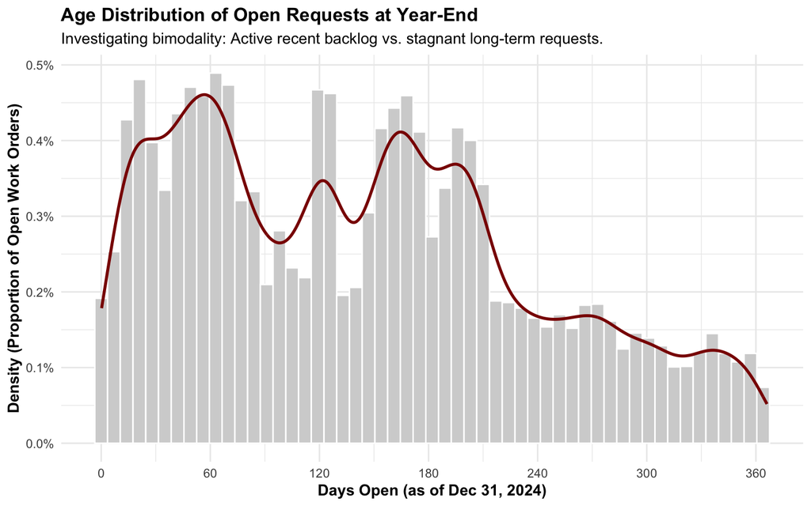

Figure 1: Age distribution of open requests at the end of 2024.

Visual inspection suggests distinct peaks in the backlog age, specifically around 60 and 170 days. A standard analytical step is determining whether these represent structural trends (such as a seasonal surge) or statistical artifacts caused by “binning bias”—the chosen width of the histogram buckets.

Because our sample size is large, we can evaluate the stability of this observation by altering the histogram resolution. If the peaks are structural, they will persist whether the data is grouped by day, week, or month.

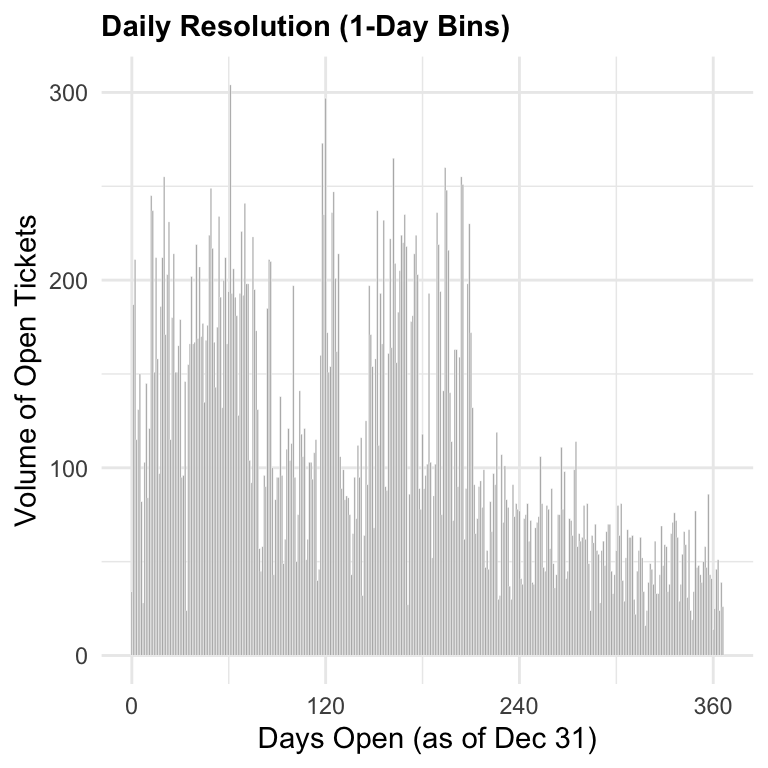

(a)

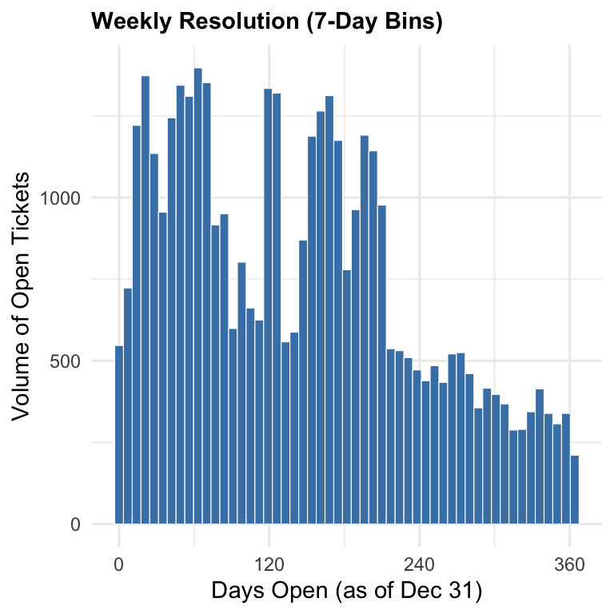

(b)

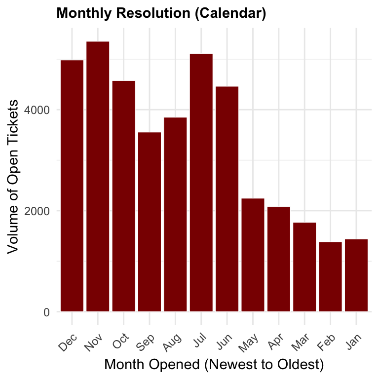

(c)

Figure 2: Histograms of age distribution of open requests at the end of 2024, with different bin sizes: (a) days, (b) weeks and (c) months.

Figure 2 demonstrates that the peaks at 60 and 170 days are stable and not binning artifacts. However, because this observation still relies on visual inspection, we must apply a formal statistical test to mathematically confirm their presence.

Hartigan’s Dip Test is a non-parametric method designed to detect multimodality (Hartigan and Hartigan 1985). The null hypothesis ($H_0$) assumes the distribution is unimodal. Mathematically, it calculates the “dip” statistic ($D$), which represents the maximum vertical distance between the empirical distribution function, $F_n(x)$, and the best-fitting unimodal distribution function, $U(x)$:
$$D = \sup_x \vert{}F_n(x) - U(x)\vert{}$$
If the data contains multiple modes (such as the 60-day and 170-day peaks), $F_n(x)$ will deviate from any fitted unimodal curve. This deviation yields a $p$-value approaching zero, rejecting the null hypothesis.

```
--- Hartigan's Dip Test for Unimodality ---
Dip Statistic (D): 0.0192
P-Value:           0e+00

Conclusion: The p-value approaches zero, mathematically rejecting unimodality.
The distinct waves in the backlog are structural realities, not binning artifacts.
```

Having established the stability of the 60-day and 170-day peaks, we investigate their potential origins by examining monthly requests that are still open at the end of 2024 by department in Figure 3.

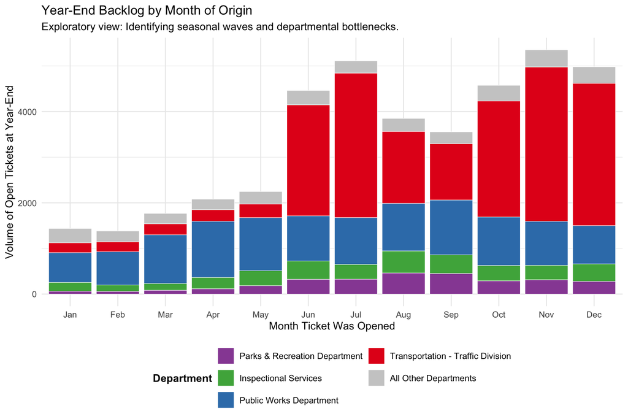

Figure 3: Visualization of departments contributions to open requests at the end of 2024 by starting month (Note that the month order is the reverse of that in Figure 2 (c)).

The visualization isolates the source of the 170-day peak: the Transportation - Traffic Division backlog increased sharply in June 2024 and remained elevated.

This increase coincides with the *Sumner Tunnel Restoration Project*. MassDOT executed a full 24/7 closure from July 5 to August 5, 2024, with June dedicated to logistical preparation—altering traffic patterns, setting detours, and modifying transit routes. This shift exceeded the Traffic Division’s baseline capacity, creating a localized backlog that persisted through year-end.

Beyond the June peak, the visualization reveals a secondary accumulation originating in October (the ~60-day backlog). Rather than a broad seasonal trend, this was a second, distinct disruption localized to the same department.

In October 2024, the MBTA executed a multi-week *shutdown of the Orange Line subway*, replacing trains with surface-level shuttle buses. To accommodate this, the Traffic Division implemented significant street-level modifications across the southwest corridor, including removing parking spaces, creating temporary bus lanes, and altering traffic flow.

Like the summer closure, this logistical pivot constrained the division’s capacity. Routine neighborhood work orders were likely deferred to manage the transit disruption, resulting in a secondary backlog just before the close of the calendar year.

## 2.3 Right-Skewed Distributions: Defining Resolution Metrics

Evaluating service resolution times using the arithmetic mean can misrepresent standard operational performance. Maintenance completion times are rarely normally distributed; instead, they typically exhibit a right skew. The majority of tasks are triaged and closed quickly, while a long tail of complex, disputed, or delayed outliers remains open for months.

This long tail shifts the mean upward, distorting the operational baseline. Consequently, the median provides a more robust central tendency metric for evaluating typical performance and establishing Service Level Agreements (SLAs).

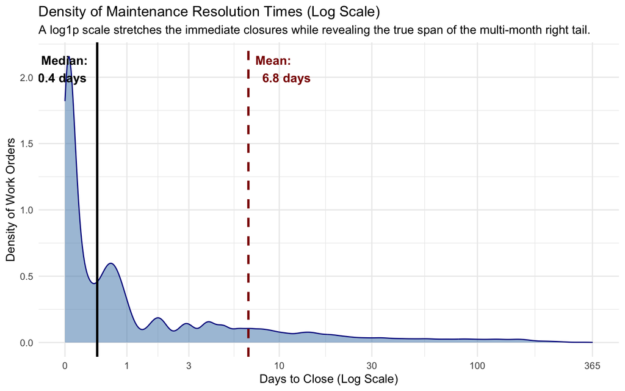

Figure 4: Density of Maintenance Resolution Times (Log Scale)

As Figure 4 illustrates, even after applying a logarithmic transformation, the distribution remains right-skewed and multi-modal. Because the data does not approximate log-normality, standard parametric statistical models (which assume normally distributed errors) are inappropriate for these data. This distributional shape necessitates the non-parametric and survival-based methodologies applied in subsequent sections.

## 2.4 Isolating Factors of Delay

To identify the variables associated with operational bottlenecks, we first establish a baseline for expected performance. In municipal and property maintenance contexts, this baseline is defined by a *Service Level Agreement (SLA)*—a standardized target time for resolving a specific request type.

Absolute resolution times lack relative context, and evaluating tickets on a binary “pass/fail” basis discards valuable variance. Instead, we calculate the *SLA Delta* (signed delay) for every closed ticket: the Actual Resolution Time minus the SLA Target Time.

> **Methodological Note:** We measure delay in absolute time (raw days) rather than a relative percentage (SLA Delta / SLA Duration) because workforce capacity constraints and operational impacts scale in days, rather than administrative ratios. Additionally, emergency triage tasks frequently have same-day SLAs (zero-day durations), which would yield mathematically undefined values if a ratio were applied.

By analyzing the continuous distribution of this SLA Delta across the dataset, we can evaluate which specific variables are most associated with extended delays.

### 2.4.1 The SLA Delta Distribution

We first analyze the overall distribution of the SLA Delta. A value of $0$ indicates the ticket was closed exactly on the deadline. Negative values represent early closures, while positive values quantify the extent to which a ticket was overdue.

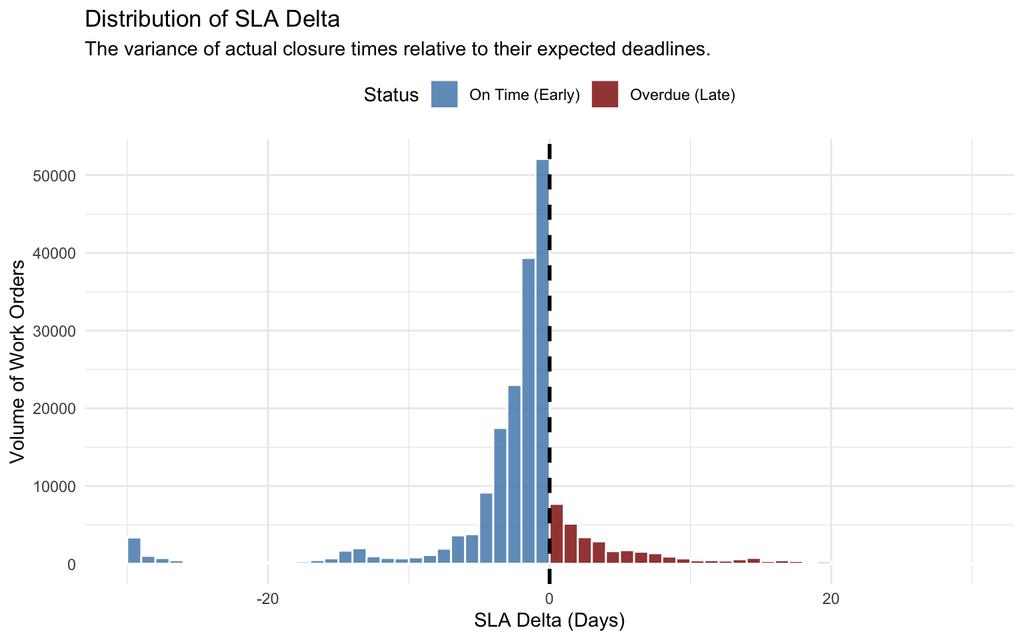

Figure 5: Distribution of SLA Delta.

This continuous distribution reveals the variance and clustering relative to the deadline. Figure 5 shows a pronounced concentration of work orders closed immediately prior to the deadline, a sharp drop-off at zero, and a right-skewed tail of overdue tickets.

### 2.4.2 Factors Associated with Resolution Variance

To identify variables associated with early or delayed closures, we test the relationship between the available categorical features (e.g., department, queue, geography) and the continuous SLA Delta.Given the prevalence of outliers, traditional parametric methods (such as ANOVA) are statistically inappropriate.

Furthermore, the large sample size ($N$) causes standard $p$-values to approach zero even for negligible differences, while the heavy right skew violates the underlying assumptions of Ordinary Least Squares (OLS) regression, rendering variance explained ($R^2$) metrics unreliable.

#### Volume-Weighted K-S Distance

o robustly evaluate categorical differences without relying on variance, we compare the *Empirical Cumulative Distribution Functions (ECDFs)* using a volume-weighted *Kolmogorov-Smirnov (K-S) statistic*.

Let $F_{global}(x)$ represent the ECDF of the SLA Delta for the entire dataset. For any given categorical factor (e.g., `department`) partitioned into $K$ subgroups, let $F_k(x)$ represent the ECDF for a specific subgroup $k$.

The standard K-S statistic, $D_k$, measures the maximum absolute vertical distance between the subgroup’s ECDF and the global ECDF:

$$D_k = \sup_x |F_k(x) - F_{global}(x)|$$

This yields a value bounded between $0$ (identical distributions) and $1$ (no distributional overlap). Because the K-S test evaluates empirical percentiles rather than mean variance, it is a non-parametric statistic and is therefore robust to outliers.

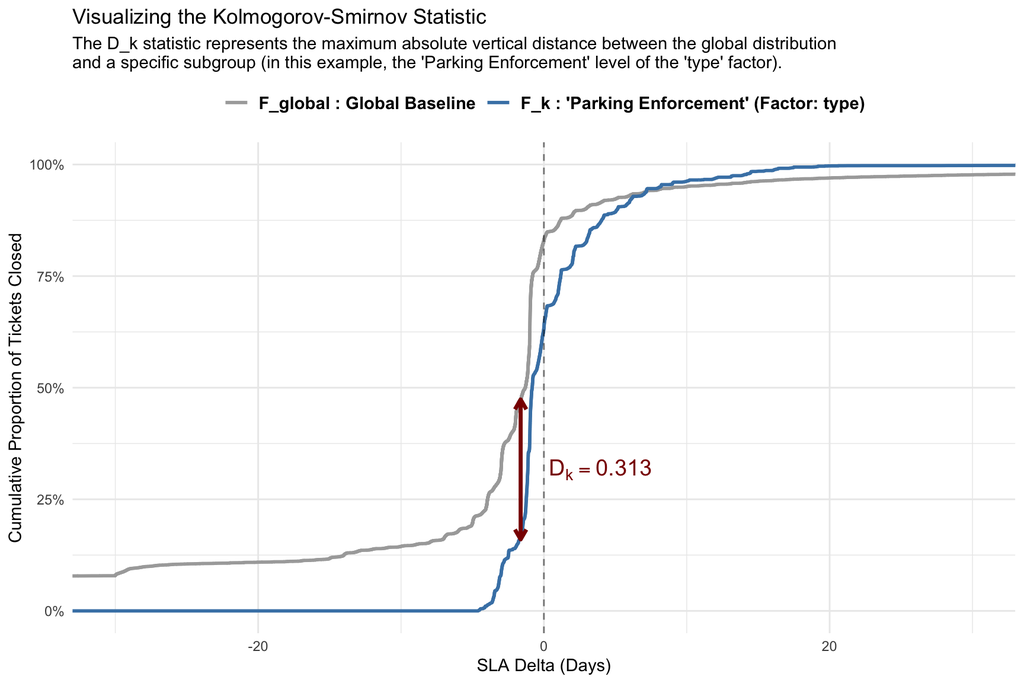

Figure 6: Graphical explanation of the Kolmogorov-Smirnov statistic.

#### Results: The Dominance of Organizational Routing

To evaluate the overall explanatory power of a categorical factor, we aggregate the $D_k$ scores across all its subgroups. Taking a simple average would artificially inflate the influence of subgroups with very low ticket volumes. Therefore, we calculate the Volume-Weighted K-S Score ($D_{wgt}$) by weighting each subgroup’s K-S statistic by its proportional ticket volume:

$$D_{wgt} = \sum_{k=1}^{K} \left( \frac{n_k}{N} \right) D_k$$

Where $n_k$ is the number of work orders in subgroup $k$, and $N$ is the total volume across all subgroups. This weighting ensures the final metric reflects operational scale, dampening variance from small subgroups while capturing deviations in high-volume queues.

Applying this non-parametric ranking to all organizational, task-based, and geographic features reveals a clear hierarchy of variance drivers displayed in Table 2.

Table 2: Factor Dependency Ranking (Weighted K-S Distance)

| Factor | Weighted K-S Score | Median P-Value |
| --- | --- | --- |
| type | 0.4307 | 4.79e-22 |
| queue | 0.3731 | 9.11e-20 |
| reason | 0.3546 | 0.00e+00 |
| subject | 0.2401 | 0.00e+00 |
| department | 0.2282 | 1.78e-05 |
| precinct | 0.1031 | 7.37e-06 |
| ward | 0.0784 | 4.43e-15 |
| location_zipcode | 0.0747 | 1.19e-20 |
| source | 0.0711 | 1.10e-194 |
| neighborhood | 0.0678 | 6.10e-29 |
| neighborhood_services_district | 0.0636 | 2.45e-40 |
| pwd_district | 0.0627 | 1.33e-20 |
| police_district | 0.0618 | 2.34e-66 |
| city_council_district | 0.0533 | 1.07e-33 |
| fire_district | 0.0519 | 1.88e-38 |

Applying this non-parametric ranking to all organizational, task-based, and geographic features reveals the hierarchy of variance drivers displayed in Table 2.

As the table illustrates, a distinct structural divide emerges: factors governing “what the work is and who does it” account for the highest variance, while factors dictating “where the work is” rank at the bottom.

To clearly visualize this distinction, we grouped these features into two primary categories—Organizational & Task Routing versus Geographic Boundaries—and plotted their K-S effect sizes in Figure 7.

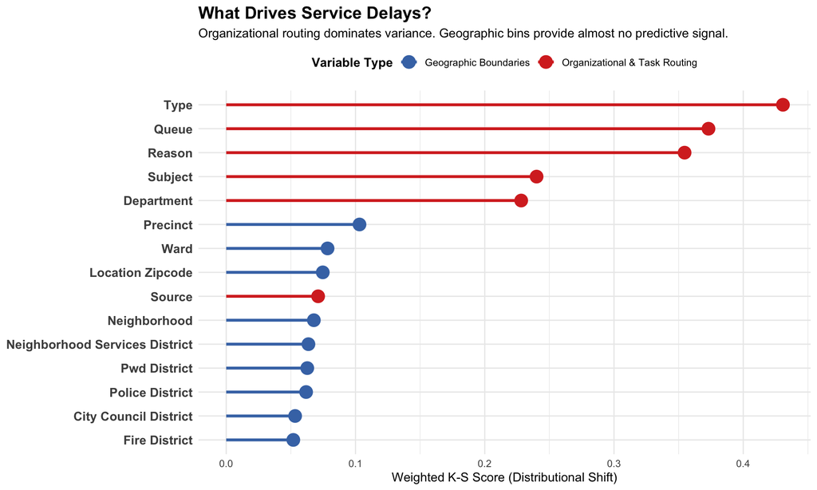

Figure 7: Visualizing the K-S Ranking: Organizational variables fundamentally drive SLA variance, while flat geographic boundaries provide minimal predictive signal.

**Task & Organizational Factors**: The variables exhibiting the highest distributional shift (`queue`, `type`, `subject`, and `department`) are organizational and functional. These factors dictate the nature of the physical task and the assigned workforce. Because a task’s nature determines its complexity, labor requirements, and necessary equipment, it acts as the primary constraint on the resolution timeline. Geographic location does not alter the physical requirements of the work itself, explaining its minimal impact on timeline variance relative to the global baseline.

**Limitations of Administrative Boundaries**: Spatial features (`precinct`, `ward`, `location_zipcode`, and municipal `district`) cluster at the bottom of the K-S results. This low ranking should not be interpreted as uniform geographic performance. Rather, it demonstrates that partitioning data by large administrative boundaries is an ineffective method for measuring localized service delivery. Categorical bins obscure physical topology by averaging out street-level disparities, as discrete variables lack spatial context regarding neighboring areas. Evaluating continuous spatial relationships requires localized autocorrelation, which is applied in Section 2.9.

### 2.4.3 Result Illustration: Extremes of Organizational Routing

To illustrate the practical impact of the K-S findings, we can evaluate performance across different digital queues.

If organizational factors strongly influence timeline variance, substantial differences should appear between distinct workflows. To examine this, we filtered for high-volume queues (handling over 500 requests) and compared the five queues with the earliest median completion times against the five queues with the most delayed median completion times.

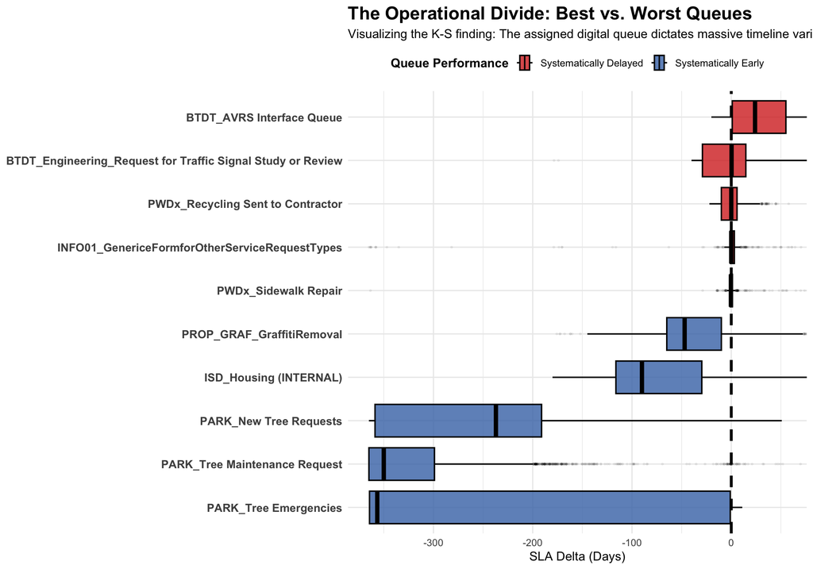

Figure 8: Contrasting SLA Delta distributions of the fastest and slowest high-volume queues. The digital routing queue strictly dictates whether a task is systematically early or structurally delayed.

**The early-closing queues (shown in blue)**, such as routine park maintenance and graffiti removal, consistently close well ahead of their target deadlines.

This comparison demonstrates the operational relevance of the K-S results: organizational routing is a primary driver of SLA timeline variance. Having evaluated categorical dimensions, the analysis next shifts to unstructured text fields, examining technician notes to evaluate whether operational signals exist outside predefined administrative bins.

## 2.5 Text Analytics: Extracting Operational Signals

Unstructured free text (such as technician `closure_reason` notes) may contain operational context absent from categorical variables. Processing these text entries requires *Natural Language Processing (NLP)* techniques.

We first apply an unsupervised machine learning pipeline to identify broad thematic patterns associated with service delays.

### 2.5.1 Unsupervised Classification

#### 2.5.1.1 Clustering

To categorize the text securely without transmitting data to external APIs, we deployed a locally hosted pipeline utilizing BERTopic (Grootendorst 2022) in conjunction with a Hugging Face sentence-transformers embedding model (Reimers and Gurevych 2019). This pipeline converts unstructured text into high-dimensional numerical embeddings, which are subsequently clustered using the HDBSCAN algorithm (McInnes et al. 2017).

Due to the computational demands of Transformer models, the classification script was executed externally in Python. The outputs were saved as a static dataset to ensure efficient document rendering.

Following the clustering phase, we extract the core themes of each group using Class-based Term Frequency-Inverse Document Frequency (c-TF-IDF). Unlike standard TF-IDF, which evaluates individual documents, c-TF-IDF aggregates all entries within a single cluster into one consolidated document. This isolates the distinct keywords that differentiate a specific operational cluster from the overall dataset.

> **Note**: The clustering algorithm assigns a topic ID of -1 to statistical outliers—tickets with highly unique text that do not fit into any broader operational pattern.

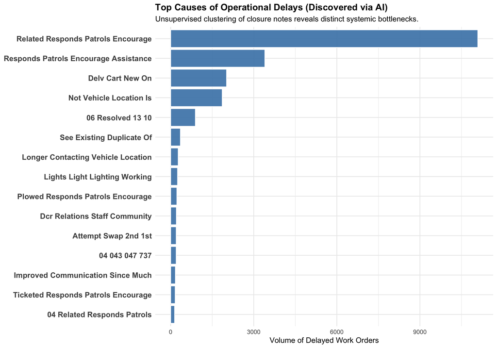

Figure 9: Volume of SLA breaches categorized by AI-discovered operational themes.

#### 2.5.1.2 Refining Labels with Local Generative AI (Ollama)

To translate these machine-readable statistics into interpretable categories, we utilized R’s httr package to query a locally hosted Llama 3 instance via Ollama (Ollama Contributors 2024). This step applies municipal context to synthesize the raw keyword strings into concise operational labels, maintaining data privacy by executing the generative inference entirely on-device.

Table 3: Automated Topic Translation via Local Llama 3 (Offline API)

Automated Topic Translation via Local Llama 3 (Offline API)

| Original c-TF-IDF String | LLM Dashboard Label |
| --- | --- |
| related responds patrols encourage | Police Community Outreach |
| longer contacting vehicle location | Vehicle Location Information |
| delv cart new on | Cart Maintenance |
| responds patrols encourage assistance | Public Safety Assistance |
| 06 resolved 13 10 | Resolved Issue |
| citation contacting been has | Traffic Enforcement |
| northern specifications pruning pruned | Tree Pruning Maintenance |
| not vehicle location is | Parking Sign |
| existing duplicate of 03 | Duplicate Request |
| code time found violation | Permit Violation |
| dial enough sincerely feel | Customer Feedback |
| 04 043 047 737 | Public Works Request |
| lights light lighting working | Street Lighting |
| invalid 06 05 03 | Equipment Maintenance |
| invalid 12 227 10 | Invalid Utility Read |

[figure not shown]

Figure 10: Volume of SLA breaches categorized by human-readable operational themes.

#### 2.5.1.3 Validation via Departmental Enrichment

Using the synthesized operational labels, we evaluate how these unsupervised clusters map to existing municipal departments to validate the accuracy of the NLP pipeline.

By calculating *Standardized Pearson Residuals* from a *Chi-Square test*, the heatmap in Figure 11 identifies which text topics are statistically over-represented in specific departments.

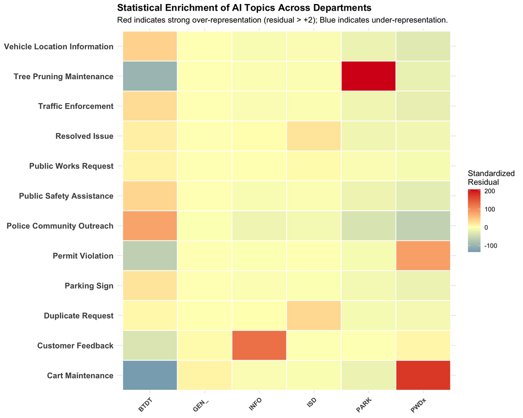

The results demonstrate expected organizational alignment. For example, “Tree Pruning Maintenance” is strongly associated with the Parks Department (`PARK`), while “Cart Maintenance” aligns with Public Works (`PWDX`). Additionally, “Customer Feedback” corresponds with the Mayor’s Hotline (`INFO`). Rather than revealing novel operational insights, these predictable associations serve as a validation step. They confirm that the unsupervised model successfully extracted accurate, department-specific themes directly from the unstructured text, verifying the pipeline’s reliability for potential downstream use of these clusters.

### 2.5.2 Structural Vocabulary Extraction

While topic modeling provided unsupervised insights, municipal data is inherently structured around strict administrative categories (e.g., `department`, `queue`, `neighborhood`). To map the specific vocabulary associated with these categories, we implemented an information-theoretic pipeline.

#### 2.5.2.1 The EMI and PMI Mathematical Framework

**Addressing Context Limits via Semantic Representation**

While *Large Language Models (LLMs)* can synthesize text, processing a category’s entire work history (often exceeding 50,000 raw tickets) is computationally prohibitive and exceeds standard context windows.

Conversely, relying on random sampling introduces representational bias: high-volume, repetitive tasks (e.g., daily trash removal) overshadow specialized, lower-volume technical work (e.g., electrical infrastructure), yielding an incomplete vocabulary profile.

To address this, we apply *Expected* and *Pointwise Mutual Information (EMI/PMI)*. Rather than sampling raw tickets, this approach transforms unstructured closure notes into a weighted array of high-signal tokens, isolating the structural vocabulary associated with a given category.

**Expected Mutual Information (EMI)**

Before evaluating category-specific vocabulary, we filter out administrative noise. Terms such as “completed,” “resident,” or “arrived” appear uniformly across categories and offer minimal structural signal. To identify and remove these terms, we calculate Expected Mutual Information (EMI). This metric aggregates a word’s ($w$) probability distribution across all categories ($c \in C$) to quantify its overall informational value:
$$EMI(w) = \sum_{c \in C} P(c \vert{} w) \cdot \log_2 \left( \frac{P(w, c)}{P(w)P(c)} \right)$$
Words yielding $EMI \le 0$ provide no structural information and are removed from the global vocabulary. This filtering reduces the free text to a core vocabulary of operational terms.

**Pointwise Mutual Information (PMI)**

Following the EMI filtering, we use Pointwise Mutual Information (PMI) to measure the association between a specific word ($w$) and a specific category ($c$). PMI compares the joint probability of the word and category against the probability of their independent occurrences:
$$PMI(w, c) = \log_2 \left( \frac{P(w, c)}{P(w)P(c)} \right)$$

- $PMI > 0$: The word co-occurs with the category more frequently than expected by chance (Attraction).
- $PMI = 0$: The word’s occurrence is independent of the category (Independence).
- $PMI < 0$: The word co-occurs with the category less frequently than expected by chance (Repulsion).

To allow for direct cross-category comparison, we divide the PMI scores by their respective maxima to calculate the Normalized PMI (NPMI):
$$NPMI(w, c) = \frac{PMI(w, c)}{-\log_2(P(c))}$$
This normalization bounds the maximum score at 1.0 across all categories.

In summary, the raw text is first filtered for high-signal words using EMI, and NPMI is subsequently applied to isolate the vocabulary associated with a specific category. This two-step approach is applied below to the `department` variable, evaluating its $\vert{}C\vert{}=19$ distinct organizational categories.

#### 2.5.2.2 Categorical Feature Selection

Prior to applying the mutual information framework, the dataset’s categorical variables were evaluated.

Table 4 and Table 5 detail the inclusion and exclusion criteria applied to define the final categorical set ($C$) for the EMI pipeline.

Table 4: Retained Analytical Factors (Independent Variables)

| Categorical Factor | Unique Levels | Analytical Purpose |
| --- | --- | --- |
| `source` | 6 | Evaluates if constituent intake channels (e.g., App vs. Call Center) generate distinct linguistic patterns. |
| `subject` | 10 | The highest-level macro-routing bucket. |
| `department` | 19 | Maps the core operational vocabulary of distinct municipal workforces. |
| `neighborhood` | 24 | Retained as a control factor to test if vocabulary changes geographically. |
| `reason` | 45 | Mid-level operational classification. |
| `type` | 173 | High-granularity operational classification. |
| `queue` | 187 | The exact digital routing destination. Expected to yield the highest-fidelity PMI signals. |

Table 5: Excluded Variables & Justification

| Excluded Variable | Levels | Primary Justification for Exclusion |
| --- | --- | --- |
| `submitted_photo` | 1 | **Zero Variance.** Cannot be used to calculate a probability distribution. |
| `on_time`, `case_status` | 2 | **Target Leakage / Scope.** We are mapping organizational topology, not SLA compliance metrics. |
| `case_title` | 3,753 | **Secondary Text.** Functions as a free-text field rather than a categorical grouping structure. |
| `precinct`, `ward`, `location_zipcode` | 37 - 255 | **Geographic Redundancy.** `neighborhood` is retained as the geographic control; finer administrative bins fracture the baseline probabilities. |
| `case_enquiry_id`, `location_street_name`, `geom_4326`, `location` | 73K - 282K | **Hyper-Granular Identifiers.** Unique row identifiers and precise coordinates fragment the denominator, causing the MI log-ratio to explode into statistical noise. |
| `open_dt`, `closed_dt`, `sla_target_dt`, `longitude`, `latitude` | Continuous | **Continuous Time & Space.** Cannot be passed into categorical mutual information models without arbitrary temporal or spatial binning. |

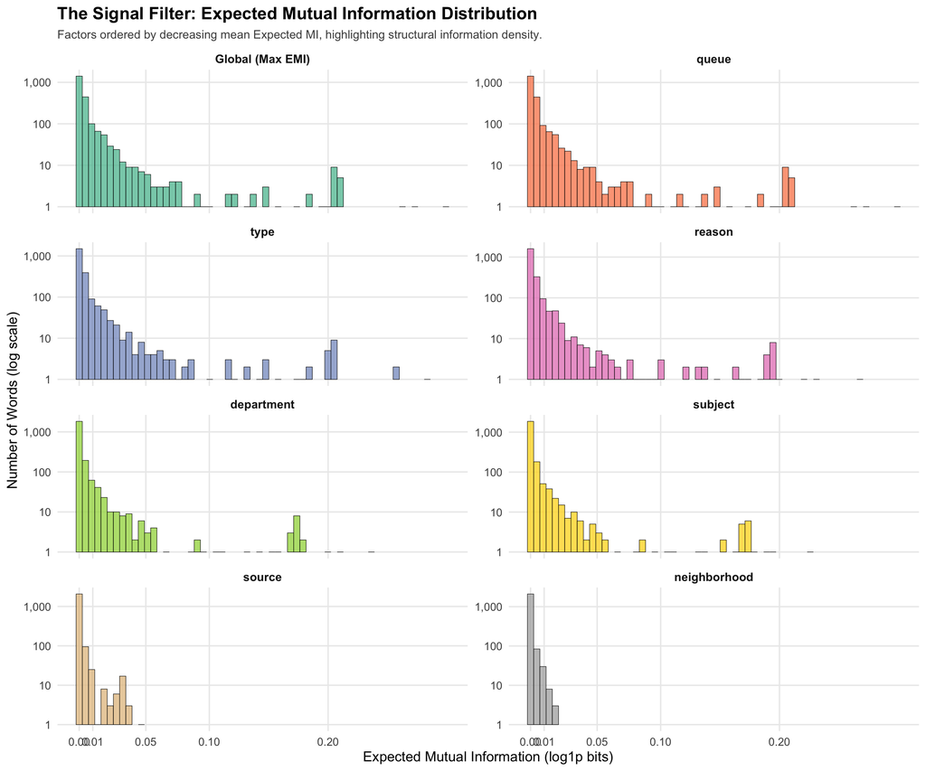

Figure 12: Distribution of Expected Mutual Information (EMI) word counts, with factors ordered from top-left to bottom-right by decreasing mean EMI.

#### 2.5.2.3 Global Signal & Functional Alignment

Applying the Expected Mutual Information (EMI) equation across the structural categories yields the distribution in Figure 12. Plotted on a logarithmic scale, the density near zero indicates that the majority of tokens are administrative noise distributed almost evenly across all categories.

In contrast, the long right tail represents the structural vocabulary that passed the $EMI > 0$ threshold with *high* information scores.

Furthermore, ranking these factors by mean EMI reveals an alignment between vocabulary density and operational function.

The factors with the highest mean EMI (`queue`, `type`, `reason`, `department`) are strictly functional. These variables dictate the nature of the physical task and the assigned workforce. Because the nature of the task determines the required tools and statuses, it also defines the operational vocabulary.

In contrast, circumstantial variables like `neighborhood` and `source` do not alter the physical requirements of the work, yielding a correspondingly low semantic footprint.

This finding corroborates the SLA variance results established via K-S testing in Section 2.4. The functional categories that govern the physical complexity of the work—and thereby influence the SLA timeline—are the same categories that exhibit the highest structural vocabulary mean EMI.

> **Note**: Using the mean EMI rather than the median EMI is better here, as it emphasizes the contribution of large EMI values.

#### 2.5.2.4 High-Signal Vocabulary by Department

Applying the mutual information framework across the 19 departments isolates the top 200 highest-signal words for each department.

The interactive table below displays these terms, ranked by their Normalized Pointwise Mutual Information (NPMI) score. Words appearing at the top of a department’s column are strongly associated with that specific workforce, indicating the physical tasks, equipment, and administrative shorthand that characterize their operations.

While automated summarization of these vocabularies is explored in subsequent sections, direct human inspection of the raw PMI rankings is highly effective for theme identification. Simply reviewing the top terms in each column reveals cohesive operational clusters—such as pest control (“burrows”, “baiting”, “droppings”) in Inspectional Services (`ISD`) or arboreal maintenance (“forestry”, “canopy”, “replant”) in Parks and Recreation (`PARK`). Because automated generative models can introduce stochastic variability, this deterministic matrix serves as a robust, standalone tool for operational discovery.

Table 6

| Rank | PWDx (Public Works) | BTDT (Transportation) | PARK (Parks and Recreation) | ISD (Inspectional Services) | GEN_ (General / 311) | INFO (Info / Hotline) | PROP (Property Management) | BWSC (Water and Sewer) | ANML (Animal Control) | BPD_ (Police Department) | DISB (Disabilities Commission) | DND_ (Neighborhood Development) | ONS_ (Neighborhood Services) |
| --- | --- | --- | --- | --- | --- | --- | --- | --- | --- | --- | --- | --- | --- |
| 1 | globe (1.00) | retrieval (1.00) | warranty (1.00) | burrows (1.00) | cd (1.00) | barking (1.00) | incumbent (1.00) | disinfected (1.00) | rb (1.00) | loud (0.91) | disability (0.93) | resolution (0.91) | date (0.00) |
| 2 | hokey (1.00) | restriping (1.00) | cassidy (1.00) | burrow (1.00) | df (1.00) | quarantine (1.00) | shadow (1.00) | departure (1.00) | lmom (0.99) | reports (0.70) | commission (0.83) | status (0.75) |  |
| 3 | ep (1.00) | hump (1.00) | forestry (1.00) | ars (1.00) | syringe (1.00) | crt (1.00) | refereed (1.00) | cb’s (1.00) | lost (0.95) | public (0.48) | office (0.63) | completed (0.47) |  |
| 4 | tote (1.00) | aim (1.00) | sh (1.00) | esd (1.00) | dt (1.00) | santana (1.00) | property’s (1.00) | jetted (1.00) | finder (0.87) | made (0.40) | contact (0.42) | resolved (0.04) |  |
| 5 | sofa (1.00) | informative (1.00) | pathfinder (1.00) | illness (1.00) | ra (1.00) | nationalgrid (1.00) | wipe (0.99) | 14x16 (1.00) | returned (0.81) | reported (0.38) | contacting (0.28) | date (0.00) |  |
| 6 | reminders (1.00) | signals (1.00) | mi (1.00) | sewers (1.00) | syr (1.00) | rabies (1.00) | chemical (0.99) | cb's (1.00) | shelter (0.80) | directly (0.21) | thank (0.17) |  |  |
| 7 | courtesy (1.00) | reface (1.00) | mfd (1.00) | baited (1.00) | jt (1.00) | gull (1.00) | chemicals (0.98) | flushed (1.00) | bm (0.79) | date (0.01) | boston (0.16) |  |  |
| 8 | fuse (1.00) | placard (1.00) | ds (1.00) | rx (1.00) | syringes (1.00) | bhn (1.00) | assets (0.98) | jf (0.99) | dog (0.78) |  | date (0.01) |  |  |
| 9 | conduit (1.00) | concurrent (1.00) | canopy (1.00) | baiting (1.00) | jg (1.00) | captured (1.00) | pressure (0.98) | cb (0.99) | pc (0.76) |  |  |  |  |
| 10 | gg (1.00) | overtimed (1.00) | replant (1.00) | droppings (1.00) | recovered (1.00) | partners (1.00) | washer (0.98) | mh (0.99) | stray (0.75) |  |  |  |  |

[output cut: 190 more lines]

#### 2.5.2.5 Vocabulary Interpretation via Local Generative AI

To provide an interpretable view of the extracted vocabulary, we integrated a local Large Language Model (LLM) into the pipeline.

Rather than processing raw operational tickets—an approach limited by context windows and noise—the LLM was restricted to the top 200 high-signal words isolated by the PMI algorithm, functioning strictly as a semantic translator. The model was initialized with a structured prompt defining its analytical role:

> **Prompt** “You are a municipal operations analyst. I am providing you with a list of the top statistically significant words extracted from the ‘closure notes’ of a specific city department, sorted by their Pointwise Mutual Information (PMI) score. This means these words represent the highly specific, unique physical tasks and vocabulary of this department. Based only on these words, write a concise, 3-sentence operational profile describing exactly what this department does in the physical world. Do not invent tasks outside of this vocabulary.”

Descriptions provided by the LLM are presented in Table 7.

> **Note**: The Boston Police Department (BPD) profile generated below relies heavily on words related to noise and public disturbances. This is because the 311 system is explicitly reserved for non-emergency municipal issues; active crimes are routed through 911 and therefore do not appear in this dataset’s vocabulary.

Table 7: Generative Translation of PMI Vocabulary Arrays into Operational Profiles

| Department | AI-Translated Operational Profile |
| --- | --- |
| **PWDx** Public Works Words: 200 \| Med NPMI: 0.98 | Based on the provided list of statistically significant words, I have compiled an operational profile that describes the physical tasks and vocabulary of the department. Here is the profile: This depa… |
| **BTDT** Transportation Words: 200 \| Med NPMI: 0.91 | Based on the provided list of words, I've compiled an operational profile describing the physical tasks and vocabulary of this department: This department is responsible for managing and maintaining v… |
| **PARK** Parks and Recreation Words: 200 \| Med NPMI: 0.93 | Based on the provided list of statistically significant words, I can create an operational profile describing the physical tasks and vocabulary of this department. Here is a 3-sentence profile: This d… |
| **ISD** Inspectional Services Words: 200 \| Med NPMI: 0.93 | Based on the top statistically significant words extracted from the 'closure notes' of a specific city department, I can create an operational profile that describes exactly what this department does … |
| **GEN_** General / 311 Words: 87 \| Med NPMI: 0.35 | Based on the provided list of words, it appears that this department is primarily responsible for conducting searches and recoveries of specific items, such as sharps and needles, in a safe and thorou… |
| **INFO** Info / Hotline Words: 200 \| Med NPMI: 0.92 | Based on the provided department words, I can create an operational profile that describes the physical tasks and vocabulary of this department. Here is a 3-sentence operational profile: This departme… |
| **PROP** Property Management Words: 76 \| Med NPMI: 0.42 | Based on the provided words, I have constructed an operational profile that describes the physical tasks and activities of this department. Here is the profile: This department is responsible for mana… |
| **BWSC** Water and Sewer Words: 134 \| Med NPMI: 0.49 | Based on the provided department words, here is a concise operational profile describing exactly what this department does in the physical world: This department appears to be responsible for managing… |
| **ANML** Animal Control Words: 82 \| Med NPMI: 0.50 | Based on the provided words, I've compiled an operational profile for this department: This department is responsible for managing and responding to lost or stray animal incidents, including tasks suc… |
| **BPD_** Police Department Words: 7 \| Med NPMI: 0.40 | Based on the provided department words, it appears that this department is responsible for producing and disseminating information to the public, likely through various reports or other written materi… |
| **DISB** Disabilities Commission Words: 8 \| Med NPMI: 0.35 | Based on the provided department words, I can infer that this department is responsible for handling and processing disability-related matters, likely involving interactions with individuals who requi… |
| **DND_** Neighborhood Development Words: 5 \| Med NPMI: 0.47 | Based on the provided words, I can infer that this department is responsible for tracking and managing the resolution of physical issues or tasks. The presence of words like "completed" and "resolved"… |

Operating on the concise arrays generated by the EMI/PMI approach, the LLM produces targeted summaries of each department’s operational footprint.

This EMI/PMI/LLM framework can be generalized to any partitioning of the dataset. For example, within property management or service request analytics, this pipeline can automatically characterize specific property groups or maintenance technician clusters.

However, this approach remains susceptible to over-interpretation when applied without *strict constraints*. As observed in certain outputs—such as misinterpreting the Mayor’s Hotline (INFO) as a wildlife rescue agency due to terms like “shelter” or “quarantine”—unconstrained language models can confabulate operational scope.

To ensure reliable interpretation, two safeguards must be maintained:

**Sufficient PMI Magnitude**: The PMI scores for the top vocabulary must be high enough, ensuring the model is not parsing low-information noise. In Table 6, each term is followed by a short representation of its PMI value, the largest possible value being 2.

**Lexical Specificity**: The input vocabulary must be operational and specific. When a department handles administrative workflows rather than distinct physical tasks (such as Neighborhood Development, `DND`, where generic terms like “completed” and “resolved” dominate), the extracted tokens lack the semantic density required for accurate text generation. In such cases, human inspection of the terms and their PMI values is preferable.

## 2.6 Seasonal Demand and System Capacity

To optimize workforce schedules, we must understand seasonal demand fluctuations. High demand alone is not problematic if the workforce is appropriately scaled to handle it.

The true operational insight lies in comparing total inbound ticket volume (Demand) against the volume of missed SLAs (System Failure) month over month. This can reveal the moments when operational capacity is overwhelmed by seasonal surges.

### 2.6.1 Citywide Macro Trends

We first look at the aggregate stress placed on Boston’s municipal infrastructure across the entire year.

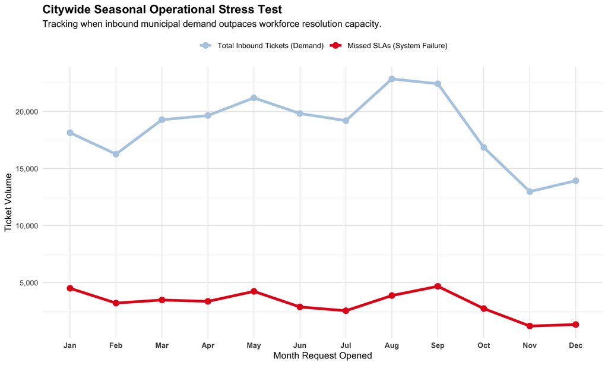

Figure 13: Citywide monthly inbound ticket demand versus the volume of resulting SLA breaches.

### 2.6.2 Departmental Micro Trends

Interestingly, the correlation between demand (blue) and system failure (red) varies significantly by department:

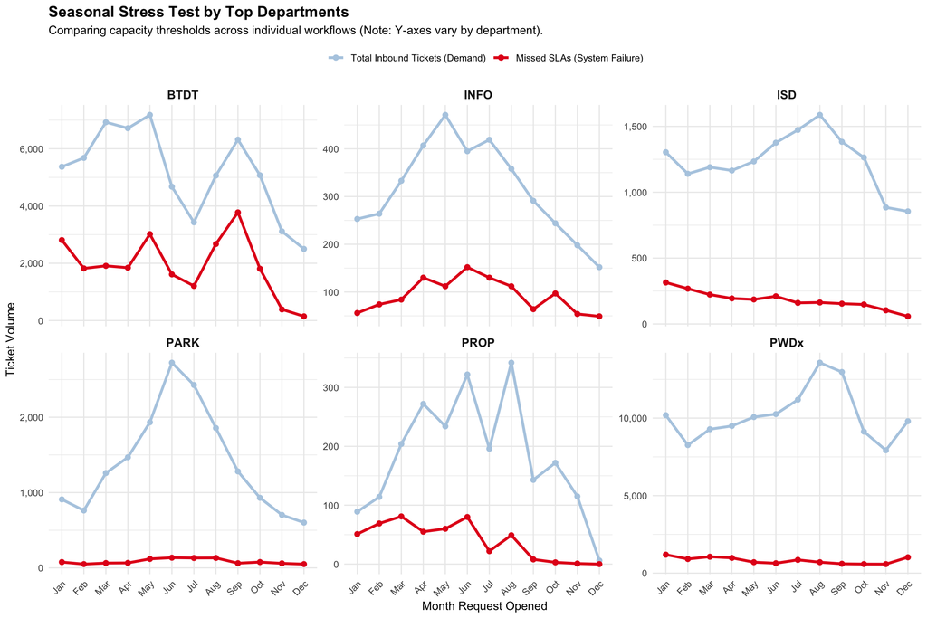

Figure 14: Departmental breakdown of monthly demand versus SLA breaches. Department abbreviations: BTDT (Transportation), INFO (Mayor’s Hotline), ISD (Inspectional Services), PARK (Parks & Recreation), PROP (Property Management), PWDx (Public Works).

**Correlated Capacity Constraints**: For departments like Transportation (`BTDT`), the Mayor’s Hotline (`INFO`), and Property Management (`PROP`), missed SLAs closely track inbound volume. When demand spikes, failure rates proportionally rise, indicating rigid capacity constraints where a static workforce cannot absorb the surge.

**Uncorrelated & Elastic Capacity**: Conversely, Parks and Recreation (`PARK`) and Public Works (`PWDx`) demonstrate a decoupled relationship. `PARK`, for example, absorbs a massive summer surge in ticket volume with almost no increase in missed SLAs. This points to highly elastic seasonal scaling, implying that the workforce is appropriately expanded (e.g., via seasonal summer hires) to match the expected environmental demand.

### 2.6.3 Extracting Seasonal Vocabulary Signatures

Initially, we attempted to evaluate temporal shifts by directly feeding ticket data of into unsupervised AI models. However, this approach failed to yield meaningful results. Because these algorithms evaluate the entire corpus simultaneously, the baseline administrative noise (e.g., “arrived,” “completed,” “spoke”) that remains constant year-round drowned out any potential seasonal signal.

To remedy this, we use the EMI/PMI/NPMI pipeline presented in Section 2.5.2.1. Rather than partitioning the data by departments, we partition a single department’s data by time ($C = Season$).

#### 2.6.3.1 Isolating Seasonal Vocabulary for Public Works (`PWDx`)

Using a seasonal partition of the Public Works (PWDx) department and the EMI, nonseasonal vocabulary is removed. We then calculate the Pointwise Mutual Information (PMI) to isolate seasonal words.

The equation for PMI is:
$$PMI(w, c) = \log_2 \left( \frac{P(w, c)}{P(w)P(c)} \right)$$
If a word is exclusive to a single season, the joint probability $P(w, c)$ equals the word probability $P(w)$, yielding the PMI maximum of $-\log_2(P(c))$.

In addition, we provide estimates of the multimodal nature of an NPMI distribution with the previously introduced (Section 2.2) Hartigan’s Dip Test. Indeed, a small p-value and large $D$ statistic will reject the hypothesis of a single mode and indicate the existence of at least one set of highly season-specific words.

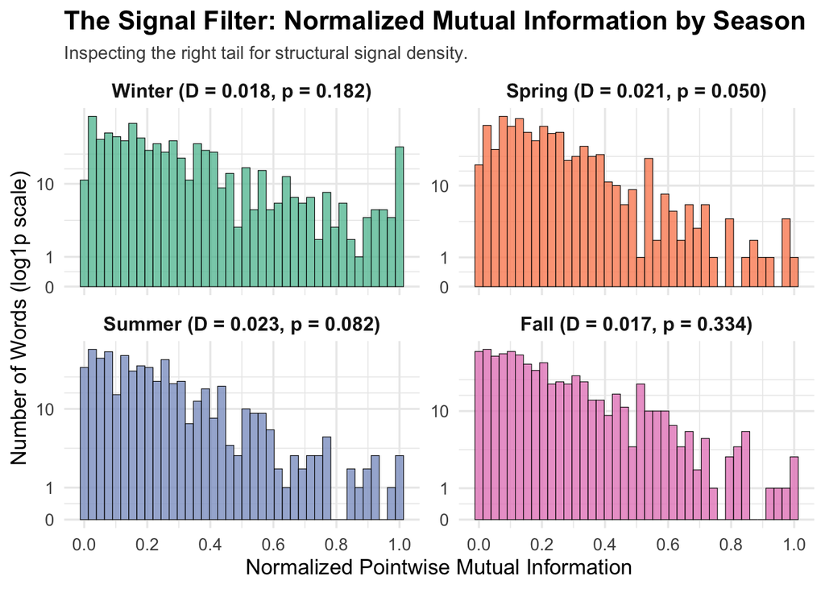

Figure 15: Distribution of positive NPMI scores for PWDx by season. Notice the strict mathematical ceiling at 1.0, representing words that are 100% exclusive to a single season.

Notice that the fall season yields a relatively large p-value (0.33), and therefore no clear indication of highly-specific vocabulary.

The interactive table Table 8 provides the extracted seasonal vocabulary for the Public Works department `PWDx`.

Table 8

| rank | Winter | Summer | Fall | Spring |
| --- | --- | --- | --- | --- |
| 1 | feb (1.00) | smcc (1.00) | october (1.00) | apr (1.00) |
| 2 | unshoveled (1.00) | aug (1.00) | nov (1.00) | mar (0.98) |
| 3 | plowed (1.00) | jul (1.00) | oct (1.00) | live (0.97) |
| 4 | salt (1.00) | jun (0.97) | sep (0.97) | prioleau (0.97) |
| 5 | plow (1.00) | fireworks (0.92) | genuinely (0.95) | reid (0.97) |
| 6 | slated (1.00) | whacked (0.92) | recognize (0.92) | arieta (0.91) |
| 7 | nonshoveled (1.00) | reallocated (0.92) | covers (0.86) | resurface (0.89) |
| 8 | mode (1.00) | recreation (0.91) | erosion (0.86) | rect (0.87) |
| 9 | dj (1.00) | overgrowth (0.89) | weights (0.86) | foot (0.87) |
| 10 | icy (1.00) | reg (0.86) | challenging (0.85) | begins (0.85) |

[output cut: 632 more lines]

#### 2.6.3.2 Vocabulary Interpretation via LLM (Ollama)

To evaluate the translation of these seasonal vectors, we conduct a blind test using a local Large Language Model (LLM). The top 30 structural words ($n=30$) for each season were fed to the LLM without identifying the department.

To test generative stability, the same prompt and parameters are executed twice (Table 9 and Table 10). Comparing the iterations highlights the variability of the generative model.

Table 9: Iteration 1: Generative Translation of Top 30 Seasonal PMI Tokens (PWDx)

| Season | Profile |
| --- | --- |
| Fall | Based on the provided word list, here is a concise operational profile: This team is primarily involved in performing physical tasks related to maintenance and repair, including sweeping and navigatin… |
| Spring | Based on the provided list of statistically significant words, I've crafted a concise operational profile: This team is primarily engaged in physical tasks related to maintenance and upgrade activitie… |
| Summer | Based on the provided words, I can infer that the team is performing physical tasks related to park or green space maintenance, likely involving tasks such as weed whacking, pruning, and sanitation to… |
| Winter | Based on the extracted words, here is a concise operational profile: This team is responsible for clearing and treating snow and ice on surfaces, utilizing various tools such as plows and shovels to p… |

Table 10: Iteration 2: Generative Translation of Top 30 Seasonal PMI Tokens (PWDx)

| Season | Profile |
| --- | --- |
| Fall | Based on the provided words, here is a concise operational profile: The team is engaged in outdoor physical tasks that involve navigating and managing machinery to perform tasks such as erosion contro… |
| Spring | Based on the provided words, I can infer that the team is performing physical tasks related to pipe and valve maintenance, as evidenced by the presence of words like "april", "prioleau", "nozzle", "tr… |
| Summer | Based on the provided list of words, I would describe the team's physical tasks as follows: The team is responsible for performing maintenance and upkeep tasks in a park or open green space, including… |
| Winter | Based on the provided list of statistically significant words, I can infer that the team is primarily responsible for snow and ice management, including tasks such as plowing, salting, and treating wi… |

Comparing the two iterations, we observe some variability of the Generative AI.

In contrast, the Fall translation shows semantic bleed caused by a mixed informational vector. Consistent with the large Hartigan’s test p-value (0.33) indicating the absence of a highly specific operational signal (Figure 15), the underlying fall array (Table 8) mixes physical nouns (sweepers, machinery) with behavioral terms (genuinely, challenging, frustrating, prompt, feedback, eager).

Because LLMs synthesize all input tokens into a single narrative, the model merges the structural and behavioral terms. Instead of isolating physical workflows, it describes a machinery crew focused on “recognizing the importance of minimizing frustration and staying eager” (Iteration 1) and addressing “difficulties and frustrations that may arise” (Iteration 2).

## 2.7 Operational Reliability (Survival Analysis)

Standard average resolution times introduce survivorship bias by excluding open tickets, which underestimates the resolution timelines of backlogged departments. To account for this right-censored data, we apply time-to-event survival analysis.

### 2.7.1 Kaplan-Meier Survival

The non-parametric Kaplan-Meier estimator models the probability of a request remaining unresolved over time, treating open tickets as censored observations.

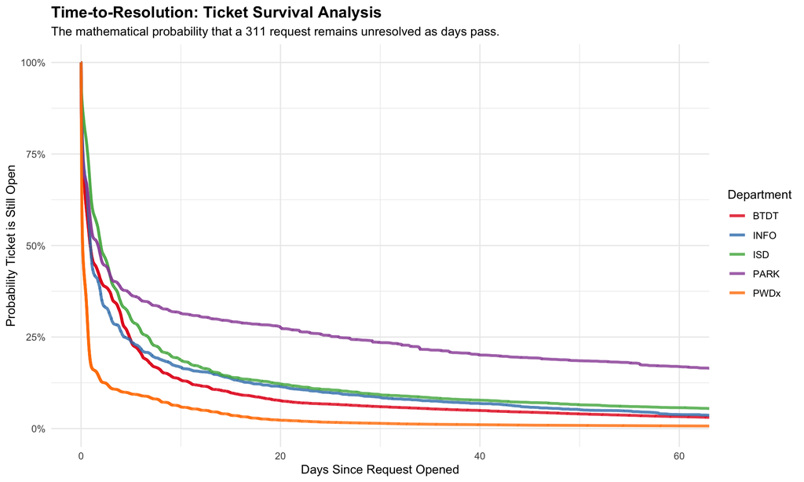

Figure 16: Kaplan-Meier survival curves estimating the probability a ticket remains open over time. Department abbreviations: BTDT (Transportation), INFO (Mayor’s Hotline), ISD (Inspectional Services), PARK (Parks & Recreation), PROP (Property Management), PWDx (Public Works).

The resulting survival curves demonstrate distinct operational profiles across departments:

**Public Works (PWDx)**: Approximately 80–85% of tickets are resolved within 48 to 72 hours, consistent with rapid, high-volume triage operations.

**Baseline Cluster (BTDT, INFO, ISD)**: These departments exhibit similar trajectories. Approximately 75% of tickets are closed within the first week, followed by a consistent resolution rate that approaches zero unresolved tickets by day 60.

**Parks and Recreation (PARK)**: The survival curve shows a pronounced right tail. While approximately 50% of tickets are resolved within the first few days, the resolution rate subsequently plateaus. By day 20, nearly 30% of tickets remain open, and roughly 20% remain unresolved past the 60-day mark. This indicates a bottleneck for long-term tickets, potentially reflecting capital budget constraints or dependencies on seasonal workflows.

### 2.7.2 Multivariate Drivers of Resolution (Cox Proportional Hazards)

Kaplan-Meier estimates provide overall resolution rates by department, but resolution time is also influenced by variables such as reporting method and the inclusion of contextual data (e.g., photographs). To isolate the effects of these covariates, we apply a Cox Proportional-Hazards model:

$$h(t\vert{}X) = h_0(t) \exp(\beta_1 X_1 + \beta_2 X_2 + \dots + \beta_p X_p)$$
Where:

- $t$ represents the time elapsed (in days) since the request was opened.
- $h(t\vert{}X)$ is the hazard rate. In this operational context, it is the probability of the ticket successfully closing at time $t$, given a specific set of operational variables $X$.
- $h_0(t)$ is the baseline hazard, representing the underlying resolution speed of the system rwhen all variables are held at their default reference levels.
- $X_1, \dots, X_p$ are the predictor variables (our covariates, such as department and reporting source).
- $\beta_1, \dots, \beta_p$ are the coefficients estimated by the regression model.

This multivariate regression exponentiates these coefficients ($\exp(\beta)$) to calculate a Hazard Ratio (HR) for each variable. In this context, a “hazard” is a positive event (closing the ticket).

- HR > 1: The variable mathematically accelerates resolution (e.g., an HR of 1.5 means the ticket is closed 50% faster than the baseline).
- HR < 1: The variable acts as a bottleneck, delaying resolution.

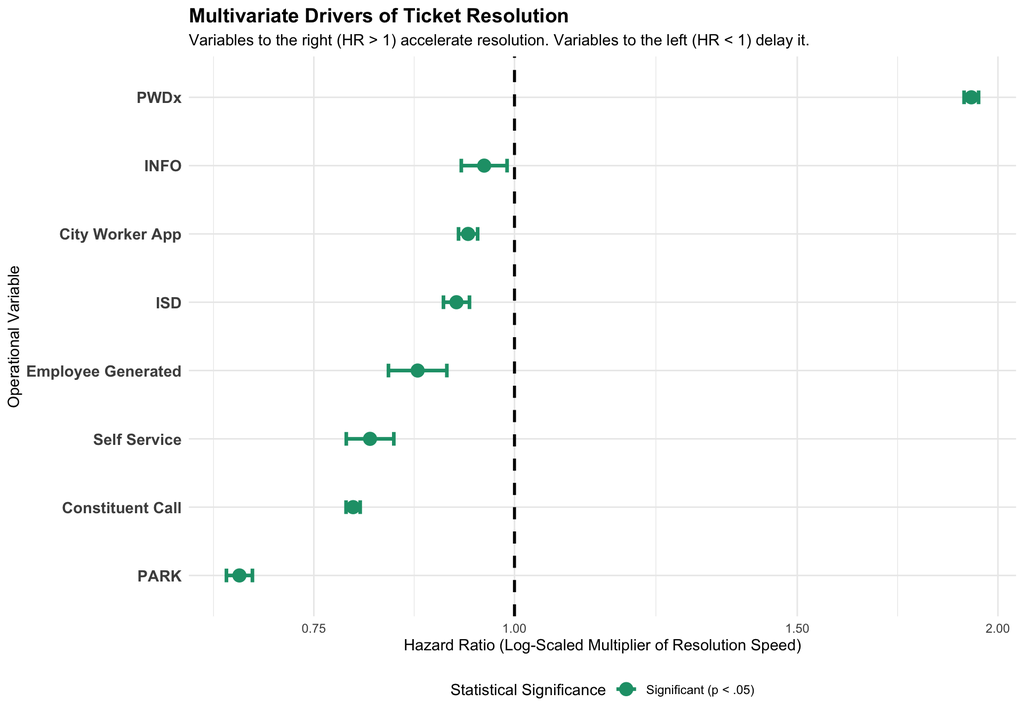

Figure 17: Hazard Ratios (Log Scale) isolating the impact of reporting sources and departments. Automated API integrations (e.g., ‘Maximo Integration’ used by the Boston 311 system) have been removed to isolate human workforce efficiency.

In the multivariate forest plot, the central dashed line at $1.00$ establishes baseline resolution speed. Dots represent the Hazard Ratio (HR)—a direct speed multiplier. Variables to the right ($HR > 1$) accelerate resolution; those to the left ($HR < 1$) act as bottlenecks. The horizontal bars indicate 95% confidence intervals. Because none cross the baseline, we can state with 95% statistical confidence that these variables genuinely impact workforce velocity, rejecting the possibility of random anomalies.

**Public Works (PWDx)** operates at nearly double the baseline speed, validating its rapid triage design.

**Parks (PARK)** faces a 35% speed deficit from long-tail bottlenecks.

## 2.8 System Stability: Queueing Theory and Backlog Velocity

While Survival Analysis evaluates the lifespan of individual tickets, it does not measure the aggregate dynamic health of a department. To diagnose systemic instability, we now use Queueing Theory.

This approach relies strictly on the mathematical balance between the Arrival Rate ($\lambda$)—tickets opened—and the Service Rate ($\mu$)—tickets closed. By calculating the net weekly queue change, we measure operational dynamics. When $\lambda > \mu$, the system enters a state of instability (growing backlog), regardless of how fast routine tickets are closed.

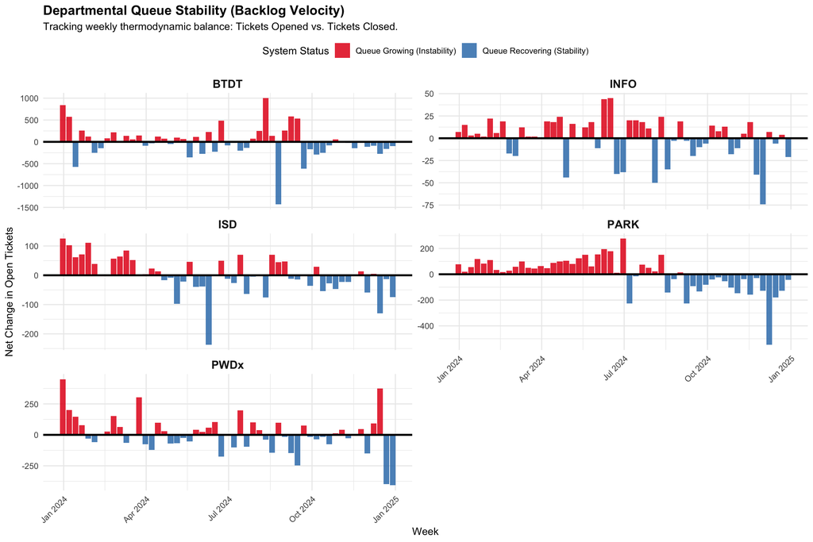

Figure 18: Queueing Stability: Weekly net change in unresolved tickets (Arrivals minus Services).Department abbreviations: BTDT (Transportation), INFO (Mayor’s Hotline), ISD (Inspectional Services), PARK (Parks & Recreation), PROP (Property Management), PWDx (Public Works).

The Backlog Velocity chart maps the behavioral pulse of the city’s workforce without relying on subjective administrative text. It reveals distinct patterns across the departments:

**PARK**: For the first six months of the year, the Parks and Recreation Department experiences a sustained period of backlog accumulation: $\lambda$ consistently exceeds $\mu$. A significant spike in closures occurs in July, aligning with the July 1st start of the municipal fiscal year (July first). This suggests a seasonal budget or resource allocation that facilitated the clearance of the accumulated queue.

**PWDx & INFO**: Public Works and the Mayor’s Hotline oscillate between small delays and immediate recoveries, hugging the baseline. This suggests a reactive, well-managed workforce operating with zero slack. They seem to absorb immediate shocks (such as the January weather surge for PWDx).

## 2.9 Spatial Equity (Geospatial Autocorrelation)

To evaluate the spatial consistency of municipal operations across neighborhoods, we apply spatial autocorrelation using Global Moran’s I (Moran 1950; Li et al. 2007).

Mapping Service Level Agreement (SLA) variance—specifically, the percentage of tickets exceeding target resolution times—across Boston’s spatial boundaries allows us to identify localized clusters. Understanding these spatial patterns can highlight underlying logistical constraints and ensure resources are equitably aligned with geographic demand.

### 2.9.1 Mapping SLA Breach Clusters

Global Moran’s I tests whether SLA exceptions are randomly distributed or spatially clustered by comparing the variance of these rates across neighboring areas against the overall citywide variance:
$$I = \frac{N}{W} \frac{\sum_i \sum_j w_{ij}(x_i - \bar{x})(x_j - \bar{x})}{\sum_i (x_i - \bar{x})^2}$$
Where:

- $N$ is the total number of spatial units (in this case, census tracts) indexed by $i$ and $j$.
- $x_i$ and $x_j$ are the SLA breach rates for tracts $i$ and $j$, respectively.
- $\bar{x}$ is the citywide average SLA breach rate.
- $w_{ij}$ is the spatial weight matrix determining how tract $i$ and tract $j$ are connected (typically $1$ if they share a physical border, and $0$ if they do not).
- $W$ is the sum of all spatial weights ($W = \sum_i \sum_j w_{ij}$).

An index near $0$ indicates a random, spatially uniform distribution of service timelines. A positive index approaching $1$ indicates significant spatial clustering of SLA exceptions. Such clustering highlights areas where potential localized logistical variables—such as complex routing networks, distinct infrastructure density, or zoned resource allocation—that present practical opportunities for operational refinement.

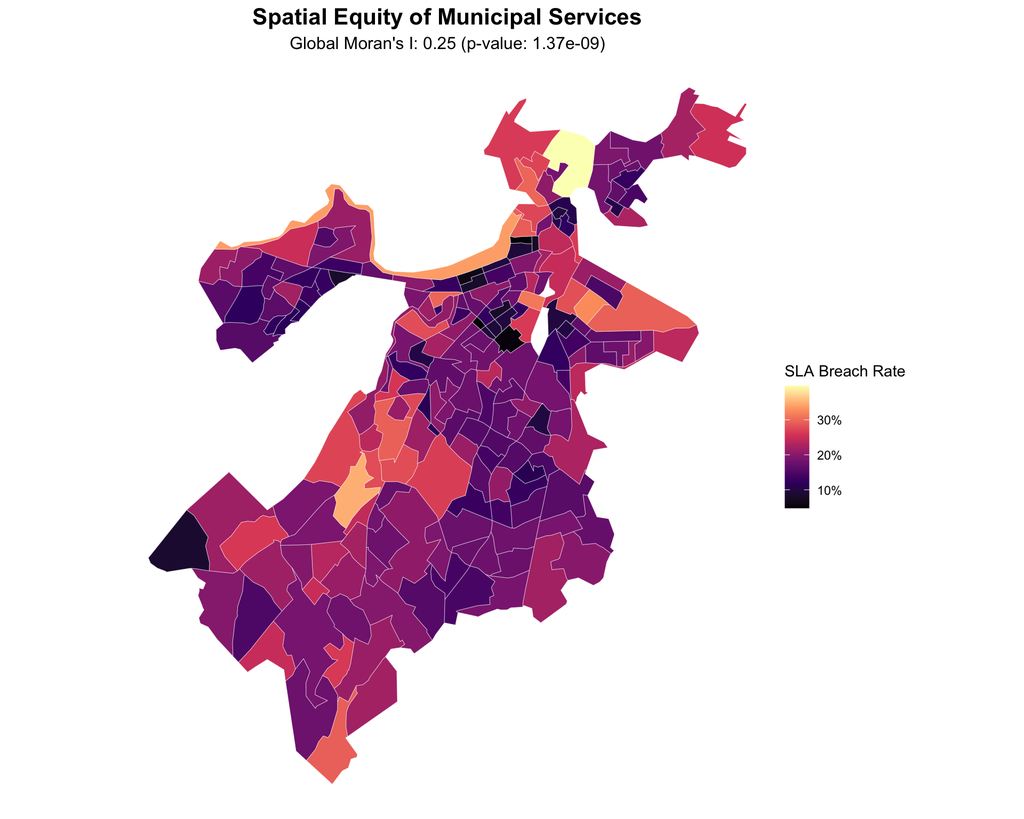

Figure 19: Geospatial distribution of SLA breach rates across Boston census tracts.

As shown in Figure 19, the spatial distribution of service timelines exhibits statistically significant clustering. The Global Moran’s I statistic of $0.25$ ($p = 1.37 \times 10^{-9}$) formally rejects the null hypothesis of spatial randomness.

Visually, the map reflects this autocorrelation: census tracts with higher SLA exception rates (the orange and yellow zones exceeding 30%) are geographically contiguous. Conversely, areas with baseline exception rates (the dark purple and black zones near 10%) form distinct, localized clusters. This spatial dependency indicates that resolution timelines are correlated with geographic location. From an operations perspective, these clusters likely represent localized logistical variables—such as specific infrastructure topologies, transit constraints, or zoned demand surges—providing clear, geographic targets for resource optimization.

### 2.9.2 Localized Clusters of SLA Variance (LISA)

Building on the global spatial autocorrelation, we apply Local Indicators of Spatial Association (LISA) (Anselin 1995) to mathematically delineate specific operational clusters. By scaling the exception rates and calculating their spatial lags, we can isolate census tracts exhibiting statistically significant spatial dependency.

Figure 20 maps these localized relationships, moving beyond simple density to identify geographic zones where resource deployment or logistical routing may require targeted optimization.

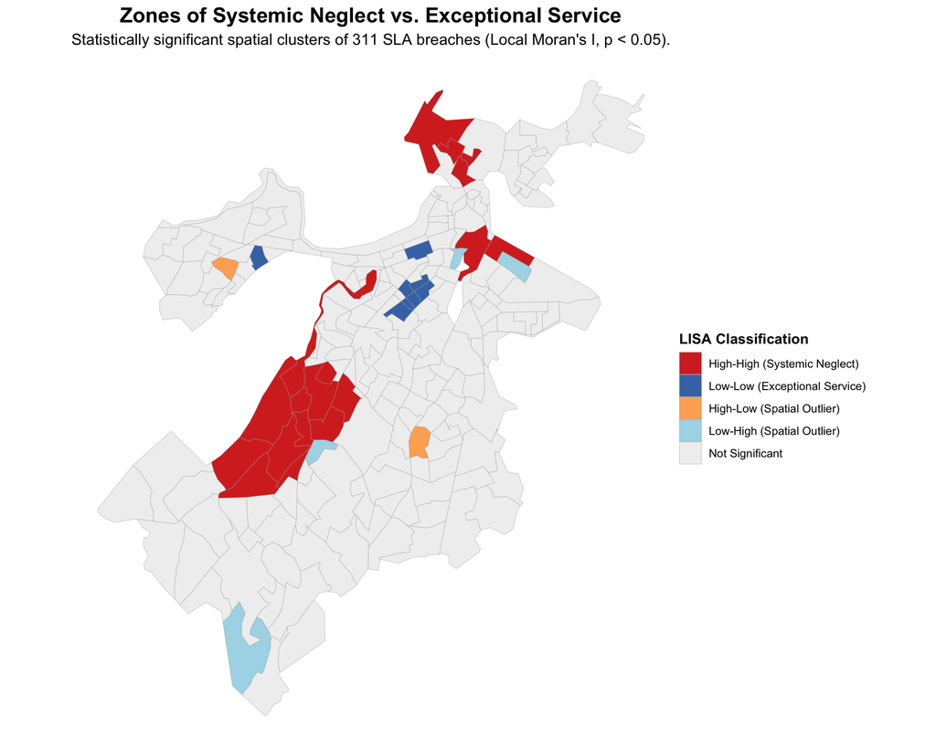

Figure 20: LISA Cluster Map isolating statistically significant zones of systemic neglect (High-High) and exceptional service (Low-Low).

**Northeast Cluster (East Boston)**: A significant zone on the northeast peninsula. Separation by Boston Harbor likely introduces unique transit bottlenecks for dispatching heavy equipment or central resources.

**Northern Cluster (Charlestown)**: A smaller concentrated pocket situated across the Charles River, where bridge access and limited entry points may constrain rapid deployment.

Conversely, “Low-Low” tracts (highlighted in blue)—indicating clusters of below-average exception rates—are situated centrally within and immediately adjacent to the downtown municipal core. This centralized efficiency likely benefits from a higher density of municipal depots and significantly shorter transit.

Ultimately, these geographic patterns indicate that service timelines are deeply tied to Boston’s physical topology. Rather than random variation, these localized pockets present actionable opportunities to adjust dispatch zoning, pre-position equipment, or revise deployment schedules to better align with the city’s unique logistical realities.

# 3. References

Anselin, Luc. 1995. “Local Indicators of Spatial Association—LISA.” *Geographical Analysis* 27 (2): 93–115.

Grootendorst, Maarten. 2022. “BERTopic: Neural Topic Modeling with a Class-Based TF-IDF Procedure.” *arXiv Preprint arXiv:2203.05794*. https://arxiv.org/abs/2203.05794.

Hartigan, John A., and Pamela M. Hartigan. 1985. “The Dip Test of Unimodality.” *The Annals of Statistics* 13 (1): 70–84. https://doi.org/10.1214/aos/1176346577.

Li, Hongfei, Catherine A. Calder, and Noel Cressie. 2007. “Beyond Moran’s i: Testing for Spatial Dependence Based on the Spatial Autoregressive Model.” *Geographical Analysis* 39 (4): 357–75.

McInnes, Leland, John Healy, and Steve Astels. 2017. “Hdbscan: Hierarchical Density Based Clustering.” *The Journal of Open Source Software* 2 (11): 205.

Moran, Patrick A. P. 1950. “Notes on Continuous Stochastic Phenomena.” *Biometrika* 37 (1/2): 17–23.

Ollama Contributors. 2024. *Ollama: Get up and Running with Large Language Models Locally*. https://ollama.com.

Reimers, Nils, and Iryna Gurevych. 2019. “Sentence-BERT: Sentence Embeddings Using Siamese BERT-Networks.” *Proceedings of the 2019 Conference on Empirical Methods in Natural Language Processing and the 9th International Joint Conference on Natural Language Processing (EMNLP-IJCNLP)*, 3982–92. https://arxiv.org/abs/1908.10084.

# Appendix: R an Python Code

## Section 1

Setup

```r
library(readr)
library(ggplot2)
library(dplyr)
library(lubridate)
library(here)
library(tidyr)
```

Data Ingestion

```r
boston_311 <- read_csv(here("data", "tmpm461rr5o.csv"))
```

## Section 2

### Section 2.1

Table 1

```r
library(dplyr)
library(DT)

# 1. Overall dimensions
cat("Dataset Dimensions:", format(nrow(boston_311), big.mark = ","), "rows and", ncol(boston_311), "columns.\n\n")
# 2. Column-summary dataframe
data_summary <- tibble(
  Column = names(boston_311),
  Type = sapply(boston_311, function(x) paste(class(x), collapse = ", ")),
  Unique_Values = sapply(boston_311, n_distinct),
  Missing_Values = sapply(boston_311, function(x) sum(is.na(x)))
)
# 3. Interactive HTML table
datatable(
  data_summary,
  rownames = FALSE,
  options = list(
    pageLength = 10,
    autoWidth = TRUE,
    dom = 'tp' # Keeps the interface clean (just table and pagination)
  ),
  caption = "Dataset Overview: Column types, unique values, and missing data."
)
```

Data Cleaning

```r
# Ingestion
boston_311 <- read_csv(here("data", "tmpm461rr5o.csv"))

# Step 1: Base Filtering and Feature Engineering
boston_mutated <- boston_311 %>%
  # Filter for completed work orders
  filter(case_status == "Closed", !is.na(closed_dt), !is.na(open_dt)) %>%
  mutate(
    # Exact resolution time
    resolution_days = as.numeric(difftime(closed_dt, open_dt, units = "days")),
    # Temporal features for seasonality and scheduling analysis
    open_month = month(open_dt, label = TRUE, abbr = TRUE),
    open_wday = wday(open_dt, label = TRUE, abbr = TRUE, week_start = 1), # Monday = 1
    open_hour = hour(open_dt)
  )

# Step 2: Quantify the data entry errors
negative_records_count <- sum(boston_mutated$resolution_days < 0, na.rm = TRUE)

# Step 3: Purge errors and finalize the Resolved Cohort
boston_clean <- boston_mutated %>%
  filter(resolution_days >= 0)

write_csv(boston_clean, here("data", "boston_clean.csv"))

# Output the validation summary
cat("Purged", format(negative_records_count, big.mark = ","), "records with negative resolution times (data entry errors).\n")
cat("Cleaned dataset contains", format(nrow(boston_clean), big.mark = ","), "closed records ready for analysis.\n")
```

### Section 2.2

Open Cases

```r
# Tickets still open at the end of 2024
boston_open <- boston_311 %>%
  filter(case_status == "Open" | is.na(closed_dt)) %>%
  mutate(
    open_month = month(open_dt, label = TRUE, abbr = TRUE),
    # Ticket age as of the end of the 2024 calendar year
    days_open_at_yearend = as.numeric(difftime(as.POSIXct("2024-12-31 23:59:59"), open_dt, units = "days"))
  )
write_csv(boston_open, here("data", "boston_open.csv"))
# Short output
cat("Isolated", format(nrow(boston_open), big.mark = ","), "open records.\n\n")
```

Figure 1

```r
ggplot(boston_open, aes(x = days_open_at_yearend)) +
  # Histogram with a 7-day binwidth to represent weekly operational cycles
  geom_histogram(aes(y = after_stat(density)), binwidth = 7, fill = "lightgray", color = "white") +
  # Density overlay to highlight the overall shape and search for bimodality
  geom_density(color = "darkred", linewidth = 1) +
  theme_minimal() +
  scale_x_continuous(breaks = seq(0, 365, by = 60)) +
  scale_y_continuous(labels = scales::percent) +
  labs(
    title = "Age Distribution of Open Requests at Year-End",
    subtitle = "Investigating bimodality: Active recent backlog vs. stagnant long-term requests.",
    x = "Days Open (as of Dec 31, 2024)",
    y = "Density (Proportion of Open Work Orders)"
  ) +
  theme(
    plot.title = element_text(face = "bold"),
    axis.title = element_text(face = "bold")
  )
```

Figure 2

```r
# Base plot for the first two charts mapping continuous days
p_base <- ggplot(boston_open, aes(x = days_open_at_yearend)) +
  theme_minimal() +
  scale_x_continuous(breaks = seq(0, 365, by = 120)) +
  labs(x = "Days Open (as of Dec 31)", y = "Volume of Open Tickets") +
  theme(plot.title = element_text(size = 11, face = "bold"))
# Daily Binning
p_base +
  geom_histogram(binwidth = 1, fill = "darkgray", color = "white", linewidth = 0.1) +
  labs(title = "Daily Resolution (1-Day Bins)")
# Weekly Binning
p_base +
  geom_histogram(binwidth = 7, fill = "steelblue", color = "white", linewidth = 0.2) +
  labs(title = "Weekly Resolution (7-Day Bins)")
# Calendar Months
boston_open %>%
  # Reverse the month levels so December (newest) is on the left, matching the 0-365 days flow
  mutate(open_month_rev = factor(open_month, levels = rev(levels(open_month)))) %>%
  ggplot(aes(x = open_month_rev)) +
  geom_bar(fill = "darkred", color = "white", linewidth = 0.2) +
  theme_minimal() +
  labs(
    title = "Monthly Resolution (Calendar)",
    x = "Month Opened (Newest to Oldest)",
    y = "Volume of Open Tickets"
  ) +
  theme(
    plot.title = element_text(size = 11, face = "bold"),
    # Angle the text slightly to ensure all 12 month labels fit cleanly
    axis.text.x = element_text(angle = 45, hjust = 1)
  )
```

Hartigan’s Dip Test

```r
library(diptest)
library(dplyr)

# Test on the continuous days open variable
dip_result <- dip.test(boston_open$days_open_at_yearend)
# Extract and format the results
dip_stat <- round(dip_result$statistic, 4)
dip_pval <- format(dip_result$p.value, scientific = TRUE, digits = 3)
# Consolidate output into a single string
conclusion_text <- if(dip_result$p.value < 0.05) {
  "Conclusion: The p-value approaches zero, mathematically rejecting unimodality.\nThe distinct waves in the backlog are structural realities, not binning artifacts."
} else {
  "Conclusion: Failed to reject unimodality."
}

final_output <- paste0(
  "--- Hartigan's Dip Test for Unimodality ---\n",
  "Dip Statistic (D): ", dip_stat, "\n",
  "P-Value:           ", dip_pval, "\n\n",
  conclusion_text, "\n"
)
cat(final_output)
```

Figure 3

```r
# Identify the top 4 departments with the most open tickets
top_open_subjects <- boston_open %>%
  count(subject, sort = TRUE) %>%
  slice_head(n = 4) %>%
  pull(subject)
# Group the data for the stacked visualization
plot_data_open <- boston_open %>%
  mutate(
    subject_grouped = ifelse(subject %in% top_open_subjects, subject, "All Other Departments"),
    # Factor to ensure the grey baseline sits at the bottom of the stack
    subject_grouped = factor(subject_grouped, levels = c("All Other Departments", top_open_subjects))
  )
# Generate the bar chart
ggplot(plot_data_open, aes(x = open_month, fill = subject_grouped)) +
  geom_bar(color = "white", linewidth = 0.2) +
  scale_fill_manual(
    values = c(
      "All Other Departments" = "grey80",
      # Using a clear, distinct color palette for the top culprits
      setNames(c("#E41A1C", "#377EB8", "#4DAF4A", "#984EA3"), top_open_subjects)
    )
  ) +
  theme_minimal() +
  labs(
    title = "Year-End Backlog by Month of Origin",
    subtitle = "Exploratory view: Identifying seasonal waves and departmental bottlenecks.",
    x = "Month Ticket Was Opened",
    y = "Volume of Open Tickets at Year-End",
    fill = "Department"
  ) +
  theme(
    legend.position = "bottom",
    legend.title = element_text(face = "bold"),
    legend.text = element_text(size = 9)
  ) +
  guides(fill = guide_legend(ncol = 2, reverse = TRUE))
```

### Section 2.3

Figure 4

```r
library(scales)

# Summary stats
res_summary <- boston_clean %>%
  summarise(
    Mean = mean(resolution_days, na.rm = TRUE),
    Median = median(resolution_days, na.rm = TRUE)
  )
ggplot(boston_clean, aes(x = resolution_days)) +
  geom_density(fill = "steelblue", color = "darkblue", alpha = 0.5) +
  geom_vline(xintercept = res_summary$Mean, color = "darkred", linetype = "dashed", linewidth = 1) +
  geom_vline(xintercept = res_summary$Median, color = "black", linetype = "solid", linewidth = 1) +
  # log1p transformation safely handles 0-day resolutions
  scale_x_continuous(
    trans = "log1p",
    breaks = c(0, 1, 3, 10, 30, 100, 365),
    labels = label_comma()
  ) +
  # Setting y = Inf and adjusting vjust pins the labels to the top of the plot
  annotate("text", x = res_summary$Mean, y = Inf,
           label = paste("Mean:\n", round(res_summary$Mean, 1), "days"),
           color = "darkred", hjust = -0.2, vjust = 1.5, size = 4, fontface = "bold") +
  annotate("text", x = res_summary$Median, y = Inf,
           label = paste("Median:\n", round(res_summary$Median, 1), "days"),
           color = "black", hjust = 1.2, vjust = 1.5, size = 4, fontface = "bold") +
  theme_minimal() +
  labs(
    title = "Density of Maintenance Resolution Times (Log Scale)",
    subtitle = "A log1p scale stretches the immediate closures while revealing the true span of the multi-month right tail.",
    x = "Days to Close (Log Scale)",
    y = "Density of Work Orders"
  )
```

### Section 2.4

#### Section 2.4.1

Figure 5

```r
# Calculate the exact delta in days
sla_delta_data <- boston_clean %>%
  filter(!is.na(sla_target_dt), subject != "Animal Control") %>%
  mutate(
    sla_delta_days = as.numeric(difftime(closed_dt, sla_target_dt, units = "days")),
    # Categorize for the plot fill
    compliance_status = ifelse(sla_delta_days <= 0, "On Time (Early)", "Overdue (Late)")
  )
# Plot the distribution of the delta
ggplot(sla_delta_data, aes(x = sla_delta_days, fill = compliance_status)) +
  # boundary = 0 added here to prevent overlapping bins at zero
  geom_histogram(binwidth = 1, boundary = 0, color = "white", alpha = 0.8) +
  # Add the hard SLA deadline reference line
  geom_vline(xintercept = 0, color = "black", linetype = "dashed", linewidth = 1) +
  scale_fill_manual(values = c("On Time (Early)" = "steelblue", "Overdue (Late)" = "darkred")) +
  # Zoom the x-axis to a relevant operational window (e.g., 30 days early to 30 days late)
  coord_cartesian(xlim = c(-30, 30)) +
  theme_minimal() +
  labs(
    title = "Distribution of SLA Delta",
    subtitle = "The variance of actual closure times relative to their expected deadlines.",
    x = "SLA Delta (Days)",
    y = "Volume of Work Orders",
    fill = "Status"
  ) +
  theme(legend.position = "top")
```

#### Section 2.4.2

Figure 6

```r
# 1. Identify a "Goldilocks" subgroup (high volume, moderate D_k around 0.35)
global_dist <- sla_delta_data$sla_delta_days

illustrative_group <- sla_delta_data %>%
  group_by(type) %>%
  filter(n() > 5000) %>%
  summarise(
    ks_stat = suppressWarnings(ks.test(sla_delta_days, global_dist)$statistic),
    .groups = "drop"
  ) %>%
  mutate(diff_from_target = abs(ks_stat - 0.35)) %>%
  arrange(diff_from_target) %>%
  slice(1)

max_type_name <- illustrative_group$type
max_type_dist <- sla_delta_data %>% filter(type == max_type_name) %>% pull(sla_delta_days)

# 2. Calculate the exact point of maximum vertical distance
x_vals <- sort(unique(c(global_dist, max_type_dist)))
ecdf_global_vals <- ecdf(global_dist)(x_vals)
ecdf_max_vals <- ecdf(max_type_dist)(x_vals)

diffs <- abs(ecdf_global_vals - ecdf_max_vals)
max_idx <- which.max(diffs)

x_max_diff <- x_vals[max_idx]
y_global <- ecdf_global_vals[max_idx]
y_max <- ecdf_max_vals[max_idx]
max_d_stat <- diffs[max_idx]

# Define dynamic labels to map math notation to the data
global_label <- "F_global : Global Baseline"
subgroup_label <- paste0("F_k : '", max_type_name, "' (Factor: type)")

# 3. Create the dataset for plotting
plot_data <- sla_delta_data %>%
  mutate(Curve = global_label) %>%
  bind_rows(
    sla_delta_data %>%
      filter(type == max_type_name) %>%
      mutate(Curve = subgroup_label)
  )

# 4. Generate the explanatory plot
ggplot(plot_data, aes(x = sla_delta_days, color = Curve)) +
  stat_ecdf(linewidth = 1) +
  # Add the vertical segment illustrating D_k
  annotate("segment", x = x_max_diff, xend = x_max_diff,
           y = y_global, yend = y_max,
           color = "darkred", linewidth = 1.2,
           arrow = arrow(ends = "both", length = unit(0.1, "inches"))) +
  # Annotate the exact D_k value mathematically
  annotate("text", x = x_max_diff + 2, y = mean(c(y_global, y_max)),
           label = paste0("D[k] == ", round(max_d_stat, 3)), parse = TRUE,
           color = "darkred", hjust = 0, size = 5, fontface = "bold") +
  # Reference line for the SLA deadline (0 days)
  geom_vline(xintercept = 0, color = "black", linetype = "dashed", alpha = 0.5) +
  # Map colors directly to the new dynamic labels
  scale_color_manual(values = setNames(c("darkgray", "steelblue"), c(global_label, subgroup_label))) +
  # Lock the zoom back to the critical operational window
  coord_cartesian(xlim = c(-30, 30)) +
  scale_y_continuous(labels = scales::percent) +
  theme_minimal() +
  labs(
    title = "Visualizing the Kolmogorov-Smirnov Statistic",
    subtitle = "The D_k statistic represents the maximum absolute vertical distance between the global distribution\nand a specific subgroup (in this example, the 'Parking Enforcement' level of the 'type' factor).",
    x = "SLA Delta (Days)",
    y = "Cumulative Proportion of Tickets Closed",
    color = NULL
  ) +
  theme(
    legend.position = "top",
    legend.text = element_text(size = 11, face = "bold")
  )
```

Volume-weighted Kolmogorov-Smirnov test

```r
library(purrr)
library(dplyr)

# Global baseline distribution
global_dist <- sla_delta_data$sla_delta_days
total_n <- nrow(sla_delta_data)
factors_to_test <- c("subject", "reason", "type", "queue", "department",
                     "fire_district", "pwd_district", "city_council_district",
                     "police_district", "neighborhood", "neighborhood_services_district",
                     "ward", "precinct", "location_zipcode", "source")
# Function to calculate the Weighted K-S Distance and extract p-values
calc_weighted_ks <- function(factor_name, data, global_dist, total_n) {
  data %>%
    group_split(!!sym(factor_name)) %>%
    map_dfr(function(df) {
      level_dist <- df$sla_delta_days
      level_n <- nrow(df)
      # Skip virtually empty levels to prevent test errors
      if(level_n < 5) return(tibble(level_n = level_n, ks_stat = 0, p_val = 1))
      # Suppress warnings for expected ties
      ks_res <- suppressWarnings(ks.test(level_dist, global_dist))
      tibble(
        level_n = level_n,
        ks_stat = ks_res$statistic,
        p_val = ks_res$p.value
      )
    }) %>%
    summarise(
      Factor = factor_name,
      Weighted_KS_Score = sum(ks_stat * (level_n / total_n)),
      Median_P_Value = median(p_val)
    )
}
# Map across all factors and rank
ks_results <- map_dfr(factors_to_test, ~calc_weighted_ks(.x, sla_delta_data, global_dist, total_n)) %>%
  arrange(desc(Weighted_KS_Score)) %>%
  mutate(
    Weighted_KS_Score = round(Weighted_KS_Score, 4),
    Median_P_Value = format(Median_P_Value, scientific = TRUE, digits = 3)
  )
```

Table 2

```r
library(knitr)

# Generate the formal Quarto table from the previous ks_results tibble
kable(
  ks_results,
  col.names = c("Factor", "Weighted K-S Score", "Median P-Value"),
  align = c('l', 'c', 'c')
)
```

Figure 7

```r
library(ggplot2)
library(stringr)
library(forcats)

# Categorize the factors and clean names for the plot
plot_ks <- ks_results %>%
  mutate(
    # Create the macro-categories based on the table's findings
    Macro_Category = if_else(
      Factor %in% c("subject", "reason", "type", "queue", "department", "source"),
      "Organizational & Task Routing",
      "Geographic Boundaries"
    ),
    # Clean up the factor names for the y-axis
    Clean_Factor = str_to_title(str_replace_all(Factor, "_", " ")),
    Clean_Factor = fct_reorder(Clean_Factor, Weighted_KS_Score)
  )

ggplot(plot_ks, aes(x = Weighted_KS_Score, y = Clean_Factor, color = Macro_Category)) +
  geom_segment(aes(x = 0, xend = Weighted_KS_Score, y = Clean_Factor, yend = Clean_Factor), linewidth = 1.2) +
  geom_point(size = 5) +
  scale_color_manual(values = c("Organizational & Task Routing" = "#d73027", "Geographic Boundaries" = "#4575b4")) +
  theme_minimal() +
  labs(
    title = "What Drives Service Delays?",
    subtitle = "Organizational routing dominates variance. Geographic bins provide almost no predictive signal.",
    x = "Weighted K-S Score (Distributional Shift)",
    y = NULL,
    color = "Variable Type"
  ) +
  theme(
    plot.title = element_text(face = "bold", size = 15),
    legend.position = "top",
    legend.title = element_text(face = "bold"),
    axis.text.y = element_text(face = "bold", size = 11)
  )
```

#### Section 2.4.3

Figure 8

```r
library(ggplot2)
library(dplyr)
library(forcats)

# 1. Identify the best and worst performing high-volume queues
queue_summary <- sla_delta_data %>%
  group_by(queue) %>%
  summarise(
    total_tickets = n(),
    median_delta = median(sla_delta_days, na.rm = TRUE)
  ) %>%
  # Isolate only robust, high-volume queues
  filter(total_tickets > 500)

# Extract the names of the top 5 and bottom 5 queues
fastest_queues <- queue_summary %>% slice_min(median_delta, n = 5) %>% pull(queue)
slowest_queues <- queue_summary %>% slice_max(median_delta, n = 5) %>% pull(queue)
target_queues <- c(fastest_queues, slowest_queues)

# 2. Filter the raw data and categorize for plotting
plot_data_extremes <- sla_delta_data %>%
  filter(queue %in% target_queues) %>%
  mutate(
    Performance = if_else(queue %in% fastest_queues, "Systematically Early", "Systematically Delayed"),
    # Reorder the factor based on median delay for a clean visual staircase
    queue = fct_reorder(queue, sla_delta_days, .fun = median, na.rm = TRUE)
  )

# Calculate dynamic axis limits to ensure all boxes fit (ignoring extreme 5% outliers)
x_lower <- quantile(plot_data_extremes$sla_delta_days, 0.05, na.rm = TRUE)
x_upper <- quantile(plot_data_extremes$sla_delta_days, 0.95, na.rm = TRUE)

# 3. Generate the Boxplot
ggplot(plot_data_extremes, aes(x = sla_delta_days, y = queue, fill = Performance)) +
  # Suppress severe outliers, thicken whiskers (linewidth), and pop the median (fatten)
  geom_boxplot(alpha = 0.8, outlier.alpha = 0.05, outlier.size = 0.5,
               color = "black", linewidth = 0.6, fatten = 3) +
  # Reference line for the exact deadline
  geom_vline(xintercept = 0, linetype = "dashed", color = "black", linewidth = 1.2) +
  # Use the dynamically calculated limits instead of hardcoded numbers
  coord_cartesian(xlim = c(x_lower, x_upper)) +
  scale_fill_manual(values = c("Systematically Early" = "#4575b4", "Systematically Delayed" = "#d73027")) +
  theme_minimal() +
  labs(
    title = "The Operational Divide: Best vs. Worst Queues",
    subtitle = "Visualizing the K-S finding: The assigned digital queue dictates massive timeline variance.",
    x = "SLA Delta (Days)",
    y = NULL,
    fill = "Queue Performance"
  ) +
  theme(
    plot.title = element_text(size = 16, face = "bold"),
    legend.position = "top",
    legend.title = element_text(face = "bold"),
    axis.text.y = element_text(size = 10, face = "bold")
  )
```

### Section 2.5

#### Section 2.5.1

##### Section 2.5.1.1

Figure 9

```r
library(readr)
library(dplyr)
library(ggplot2)
library(stringr)
library(here)

# Read ONLY the newly generated AI columns and the Ticket ID
ai_results <- read_csv(here("data", "boston_bertopic_results.csv")) %>%
  select(case_enquiry_id, topic_id, ai_topic_name)
# Join the AI topics to your existing SLA dataset and filter
ai_plot_data <- sla_delta_data %>%
  inner_join(ai_results, by = "case_enquiry_id") %>%
  filter(compliance_status == "Overdue (Late)", topic_id != -1) %>%
  mutate(
    clean_topic = str_remove(ai_topic_name, "^\\d+_"),
    clean_topic = str_replace_all(clean_topic, "_", " "),
    clean_topic = str_to_title(clean_topic)
  ) %>%
  count(clean_topic, sort = TRUE) %>%
  slice_head(n = 15)
# Generate the visualization
ggplot(ai_plot_data, aes(x = n, y = reorder(clean_topic, n))) +
  geom_col(fill = "steelblue", color = "white", alpha = 0.9) +
  theme_minimal() +
  labs(
    title = "Top Causes of Operational Delays (Discovered via AI)",
    subtitle = "Unsupervised clustering of closure notes reveals distinct systemic bottlenecks.",
    x = "Volume of Delayed Work Orders",
    y = NULL
  ) +
  theme(
    plot.title = element_text(face = "bold"),
    axis.text.y = element_text(size = 11, face = "bold")
  )
```

##### Section 2.5.1.2

Table 3

```r
library(dplyr)
library(purrr)
library(stringr)
library(readr)
library(here)
library(knitr)
library(httr)

# CLEAN FIRST, then get the Top 15 Unique topics
ai_results <- read_csv(here("data", "boston_bertopic_results.csv"))
topic_summary <- ai_results %>%
  filter(topic_id != -1) %>%
  mutate(
    clean_raw_topic = str_remove(ai_topic_name, "^\\d+_"),
    clean_raw_topic = str_replace_all(clean_raw_topic, "_", " ")
  ) %>%
  count(clean_raw_topic, sort = TRUE) %>%
  slice_head(n = 15)
# Direct Local API with the Proper Persona
translate_topic <- function(messy_string) {
  sys_prompt <- "You are an expert municipal data analyst for the City of Boston. You classify messy 311 work order keywords."
  user_prompt <- paste0(
    "Translate this messy keyword string into a clean, 3-to-4 word operational category label (e.g., 'Equipment Maintenance', 'Duplicate Request').\n\n",
    "Return ONLY the label. Do not include quotes, formatting, or introductory text.\n\n",
    "Keyword: ", messy_string
  )
  # Send offline request directly to local Mac memory
  res <- tryCatch({
    POST(
      url = "http://localhost:11434/api/generate",
      body = list(
        model = "llama3",
        prompt = user_prompt,
        system = sys_prompt,
        stream = FALSE
      ),
      encode = "json",
      timeout(30)
    )
  }, error = function(e) return(NULL))
  if (is.null(res) || status_code(res) != 200) return("API Connection Failed")
  raw_text <- content(res, as = "parsed", type = "application/json")$response
  # Strip out any markdown or quotes the LLM tries to sneak in
  clean_label <- str_remove_all(raw_text, '["*]') %>% str_trim()
  return(as.character(clean_label))
}
# Loop through the 15 topics
llm_clean_names <- map_chr(topic_summary$clean_raw_topic, translate_topic)
# Build and print the crosswalk table
topic_crosswalk <- tibble(
  `Original c-TF-IDF String` = topic_summary$clean_raw_topic,
  `LLM Dashboard Label` = llm_clean_names
)
kable(topic_crosswalk, caption = "Automated Topic Translation via Local Llama 3 (Offline API)")
```

Figure 10

```r
# Re-isolate the delayed tickets and format the topic strings to match the crosswalk
ai_plot_data_translated <- sla_delta_data %>%
  inner_join(ai_results, by = "case_enquiry_id") %>%
  filter(compliance_status == "Overdue (Late)", topic_id != -1) %>%
  mutate(
    clean_raw_topic = str_remove(ai_topic_name, "^\\d+_"),
    clean_raw_topic = str_replace_all(clean_raw_topic, "_", " ")
  ) %>%
  count(clean_raw_topic, sort = TRUE) %>%
  slice_head(n = 15) %>%
  # Join the translated labels generated by Ollama
  left_join(topic_crosswalk, by = c("clean_raw_topic" = "Original c-TF-IDF String")) %>%
  # Fallback to Title Case just in case a delayed topic wasn't in the global Top 15
  mutate(
    final_label = ifelse(is.na(`LLM Dashboard Label`), str_to_title(clean_raw_topic), `LLM Dashboard Label`)
  )

# Generate the updated visualization
ggplot(ai_plot_data_translated, aes(x = n, y = reorder(final_label, n))) +
  geom_col(fill = "steelblue", color = "white", alpha = 0.9) +
  theme_minimal() +
  labs(
    title = "Top Causes of Operational Delays (Translated via AI)",
    subtitle = "Unsupervised clustering of closure notes, categorized by local Llama 3.",
    x = "Volume of Delayed Work Orders",
    y = NULL
  ) +
  theme(
    plot.title = element_text(face = "bold"),
    axis.text.y = element_text(size = 11, face = "bold")
  )
```

##### Section 2.5.1.3

Figure 11

```r
library(readr)
library(dplyr)
library(tidyr)
library(ggplot2)
library(stringr)
library(here)

# Load the AI results and join the LLM translated labels
ai_df <- read_csv(here("data", "boston_bertopic_results.csv")) %>%
  filter(topic_id != -1, !is.na(department)) %>%
  mutate(
    clean_raw_topic = str_remove(ai_topic_name, "^\\d+_"),
    clean_raw_topic = str_replace_all(clean_raw_topic, "_", " ")
  ) %>%
  # Bring in the translations from the previous chunk
  left_join(topic_crosswalk, by = c("clean_raw_topic" = "Original c-TF-IDF String")) %>%
  mutate(
    # Fallback to the title-cased raw topic if it wasn't in our Top 15 translated list
    Final_Label = ifelse(is.na(`LLM Dashboard Label`), str_to_title(clean_raw_topic), `LLM Dashboard Label`)
  )
# Focus on top departments and top topics to keep the grid readable
top_depts  <- ai_df %>% count(department, sort = TRUE) %>% slice_head(n = 6) %>% pull(department)
top_topics <- ai_df %>% count(Final_Label, sort = TRUE) %>% slice_head(n = 12) %>% pull(Final_Label)
filtered_df <- ai_df %>%
  filter(department %in% top_depts, Final_Label %in% top_topics)
# Create a contingency table and run Chi-Square to get Standardized Residuals
contingency_matrix <- table(filtered_df$Final_Label, filtered_df$department)
chisq_res <- chisq.test(contingency_matrix)
# Convert residuals back to a tidy dataframe for ggplot
enrichment_data <- as.data.frame(chisq_res$stdres) %>%
  rename(Topic = Var1, Department = Var2, StdResidual = Freq)
# Visualize as an Enrichment Heatmap using the clean LLM labels
ggplot(enrichment_data, aes(x = Department, y = Topic, fill = StdResidual)) +
  geom_tile(color = "white", linewidth = 0.5) +
  scale_fill_gradient2(
    low = "#2b83ba", mid = "#ffffbf", high = "#d7191c",
    midpoint = 0,
    name = "Standardized\nResidual"
  ) +
  theme_minimal() +
  labs(
    title = "Statistical Enrichment of AI Topics Across Departments",
    subtitle = "Red indicates strong over-representation (residual > +2); Blue indicates under-representation.",
    x = NULL,
    y = NULL
  ) +
  theme(
    plot.title = element_text(face = "bold"),
    axis.text.x = element_text(angle = 45, hjust = 1, face = "bold"),
    axis.text.y = element_text(size = 11, face = "bold")
  )
```

#### Section 2.5.2

##### Section 2.5.2.1

##### Section 2.5.2.2

Table 4

```r
library(tibble)
library(knitr)

retained_factors <- tribble(
  ~`Categorical Factor`, ~`Unique Levels`, ~`Analytical Purpose`,
  "`source`", "6", "Evaluates if constituent intake channels (e.g., App vs. Call Center) generate distinct linguistic patterns.",
  "`subject`", "10", "The highest-level macro-routing bucket.",
  "`department`", "19", "Maps the core operational vocabulary of distinct municipal workforces.",
  "`neighborhood`", "24", "Retained as a control factor to test if vocabulary changes geographically.",
  "`reason`", "45", "Mid-level operational classification.",
  "`type`", "173", "High-granularity operational classification.",
  "`queue`", "187", "The exact digital routing destination. Expected to yield the highest-fidelity PMI signals."
)

kable(retained_factors, align = c('l', 'c', 'l'))
```

Table 5

```r
library(tibble)
library(knitr)

excluded_factors <- tribble(
  ~`Excluded Variable`, ~`Levels`, ~`Primary Justification for Exclusion`,
  "`submitted_photo`", "1", "**Zero Variance.** Cannot be used to calculate a probability distribution.",
  "`on_time`, `case_status`", "2", "**Target Leakage / Scope.** We are mapping organizational topology, not SLA compliance metrics.",
  "`case_title`", "3,753", "**Secondary Text.** Functions as a free-text field rather than a categorical grouping structure.",
  "`precinct`, `ward`, `location_zipcode`", "37 - 255", "**Geographic Redundancy.** `neighborhood` is retained as the geographic control; finer administrative bins fracture the baseline probabilities.",
  "`case_enquiry_id`, `location_street_name`, `geom_4326`, `location`", "73K - 282K", "**Hyper-Granular Identifiers.** Unique row identifiers and precise coordinates fragment the denominator, causing the MI log-ratio to explode into statistical noise.",
  "`open_dt`, `closed_dt`, `sla_target_dt`, `longitude`, `latitude`", "Continuous", "**Continuous Time & Space.** Cannot be passed into categorical mutual information models without arbitrary temporal or spatial binning."
)

kable(excluded_factors, align = c('l', 'c', 'l'))
```

Calls to EMI and PMI Scripts

```r
# ==============================================================================
# Workflow Tracking:
# The vocabulary data displayed below is generated by the following scripts:
source("../R/expected_mutual_information.R") # (Global vocabulary filtering)
source("../R/pointwise_mutual_information.R") # (Department-specific PMI mapping)
# ==============================================================================
```

Figure 12

```r
library(ggplot2)
library(dplyr)
library(scales)
library(readr)

mi_results <- read_csv("../data/mi_results.csv", show_col_types = FALSE)

# 1. Calculate mean Expected MI per factor to establish a decreasing sort order
factor_ranking <- mi_results %>%
  group_by(factor) %>%
  summarise(mean_emi = mean(expected_mi, na.rm = TRUE)) %>%
  arrange(desc(mean_emi)) %>%
  pull(factor)

# 2. Create the "Global" summary pseudo-factor (Max EMI across all factors for each word)
global_mi <- mi_results %>%
  group_by(word) %>%
  summarise(expected_mi = max(expected_mi, na.rm = TRUE)) %>%
  mutate(factor = "Global (Max EMI)")

# 3. Combine data and set factor levels: Global first, followed by factors ordered by mean EMI
plot_data <- bind_rows(global_mi, mi_results) %>%
  mutate(factor = factor(factor, levels = c("Global (Max EMI)", factor_ranking)))

# 4. Generate the 4x2 faceted plot
ggplot(plot_data, aes(x = expected_mi, fill = factor)) +
  geom_histogram(bins = 60, color = "black", linewidth = 0.2, alpha = 0.8) +
  facet_wrap(~ factor, scales = "free_y", ncol = 2) +
  # Log-transform the X-axis to spread out the dense region near zero
  scale_x_continuous(
    trans = "log1p",
    breaks = c(0, 0.01, 0.05, 0.1, 0.2),
    labels = scales::label_number(accuracy = 0.01)
  ) +
  # Log-transform the Y-axis counts
  scale_y_log10(
    labels = scales::comma,
    breaks = c(1, 10, 100, 1000, 10000)
  ) +
  theme_minimal(base_size = 13) +
  scale_fill_brewer(palette = "Set2") +
  labs(
    title = "The Signal Filter: Expected Mutual Information Distribution",
    subtitle = "Factors ordered by decreasing mean Expected MI, highlighting structural information density.",
    x = "Expected Mutual Information (log1p bits)",
    y = "Number of Words (log scale)",
    fill = "Factor"
  ) +
  theme(
    plot.title = element_text(face = "bold", size = 16),
    plot.subtitle = element_text(size = 11, color = "grey30"),
    strip.text = element_text(face = "bold", size = 11),
    legend.position = "none",
    panel.grid.minor = element_blank()
  )
```

##### Section 2.5.2.3

##### Section 2.5.2.4

Table 6

```r
library(readr)
library(dplyr)
library(DT)
library(tibble)

# 1. Map short codes to full department names
dept_mapping <- tribble(
  ~code, ~full_name,
  "PWDx", "Public Works",
  "BTDT", "Transportation",
  "PARK", "Parks and Recreation",
  "ISD", "Inspectional Services",
  "GEN_", "General / 311",
  "BWSC", "Water and Sewer",
  "INFO", "Info / Hotline",
  "ANML", "Animal Control",
  "PROP", "Property Management",
  "BPD_", "Police Department",
  "DISB", "Disabilities Commission",
  "DND_", "Neighborhood Development",
  "ONS_", "Neighborhood Services"
)

# Load the wide-format PMI data
pmi_wide <- read_csv("../data/department_all19_pmi_excel.csv", show_col_types = FALSE)

# Clean the dataframe for HTML display
pmi_display <- pmi_wide %>%
  select(ends_with("_word")) %>%
  rename_with(~ sub("_word$", "", .x))

# Rename the columns to include full names based on the mapping
new_col_names <- sapply(names(pmi_display), function(col) {
  full_name <- dept_mapping$full_name[dept_mapping$code == col]
  if (length(full_name) > 0) paste0(col, " (", full_name, ")") else col
})
names(pmi_display) <- new_col_names

pmi_display <- pmi_display %>% mutate(Rank = row_number(), .before = 1)

# Generate the interactive DataTable
datatable(
  pmi_display,
  rownames = FALSE,
  class = 'display compact',
  caption = "Top 200 Operational Words by Department (Ranked by NPMI, Tie-broken by Volume). The NPMI value is provided with each word.",
  options = list(
    pageLength = 20,
    scrollX = TRUE,
    dom = 'ftip',
    searchHighlight = TRUE
  )
) %>%
  formatStyle(columns = names(pmi_display), fontSize = '13px')
```

[output not shown]

##### Section 2.5.2.5

Table 7

```r
library(readr)
library(dplyr)
library(knitr)
library(kableExtra)
library(tibble)

# 1. Map short codes to full department names
dept_mapping <- tribble(
  ~code, ~full_name,
  "PWDx", "Public Works",
  "BTDT", "Transportation",
  "PARK", "Parks and Recreation",
  "ISD", "Inspectional Services",
  "GEN_", "General / 311",
  "BWSC", "Water and Sewer",
  "INFO", "Info / Hotline",
  "ANML", "Animal Control",
  "PROP", "Property Management",
  "BPD_", "Police Department",
  "DISB", "Disabilities Commission",
  "DND_", "Neighborhood Development",
  "ONS_", "Neighborhood Services"
)

# Load the LLM-generated profiles
llm_profiles <- read_csv("../data/department_profiles_llm.csv", show_col_types = FALSE)

# Clean and format for display
display_profiles <- llm_profiles %>%
  # Filter out small departments that lacked sufficient vocabulary for a profile
  filter(!grepl("Insufficient vocabulary", operational_profile, ignore.case = TRUE)) %>%
  # Join full names
  left_join(dept_mapping, by = c("department" = "code")) %>%
  # Format the Department column to stack the code and the full name
  mutate(
    Department = paste0("<b>", department, "</b><br><span style='font-size:0.85em; color:gray;'>", full_name, "</span>")
  ) %>%
  select(Department, `AI-Translated Operational Profile` = operational_profile)

# Render a styled HTML table with strict column widths to enforce text wrapping
kable(display_profiles, format = "html", escape = FALSE) %>%
  kable_styling(bootstrap_options = c("striped", "hover"), full_width = FALSE) %>%
  column_spec(1, width = "20%") %>%
  column_spec(2, width = "80%")
```

[output not shown]

### Section 2.6

Figure 13

```r
library(dplyr)
library(ggplot2)
library(lubridate)
library(tidyr)
library(scales)

# Base dataset with extracted month
seasonal_base <- sla_delta_data %>%
  mutate(created_month = month(open_dt, label = TRUE, abbr = TRUE))
# Global Aggregation
global_summary <- seasonal_base %>%
  group_by(created_month) %>%
  summarise(
    Total_Demand = n(),
    SLA_Breaches = sum(compliance_status == "Overdue (Late)", na.rm = TRUE),
    .groups = "drop"
  ) %>%
  pivot_longer(
    cols = c(Total_Demand, SLA_Breaches),
    names_to = "Metric",
    values_to = "Volume"
  ) %>%
  mutate(
    Metric = factor(Metric, levels = c("Total_Demand", "SLA_Breaches"),
                    labels = c("Total Inbound Tickets (Demand)", "Missed SLAs (System Failure)"))
  )
# Build the global seasonal overlay
ggplot(global_summary, aes(x = created_month, y = Volume, group = Metric, color = Metric)) +
  geom_line(linewidth = 1.5) +
  geom_point(size = 3) +
  scale_y_continuous(labels = comma) +
  scale_color_manual(values = c("Total Inbound Tickets (Demand)" = "#b3cde3",
                                "Missed SLAs (System Failure)" = "#e41a1c")) +
  theme_minimal() +
  labs(
    title = "Citywide Seasonal Operational Stress Test",
    subtitle = "Tracking when inbound municipal demand outpaces workforce resolution capacity.",
    x = "Month Request Opened",
    y = "Ticket Volume",
    color = NULL
  ) +
  theme(
    plot.title = element_text(face = "bold", size = 14),
    legend.position = "top",
    axis.text.x = element_text(face = "bold")
  )
```

[output not shown]

#### Section 2.6.2

Figure 14

```r
# Find the top 6 departments by overall ticket volume
top_depts_season <- seasonal_base %>%
  count(department, sort = TRUE) %>%
  slice_head(n = 6) %>%
  pull(department)
# Departmental Aggregation
dept_summary <- seasonal_base %>%
  filter(department %in% top_depts_season) %>%
  group_by(department, created_month) %>%
  summarise(
    Total_Demand = n(),
    SLA_Breaches = sum(compliance_status == "Overdue (Late)", na.rm = TRUE),
    .groups = "drop"
  ) %>%
  pivot_longer(
    cols = c(Total_Demand, SLA_Breaches),
    names_to = "Metric",
    values_to = "Volume"
  ) %>%
  mutate(
    Metric = factor(Metric, levels = c("Total_Demand", "SLA_Breaches"),
                    labels = c("Total Inbound Tickets (Demand)", "Missed SLAs (System Failure)"))
  )
# Build the faceted visualization
ggplot(dept_summary, aes(x = created_month, y = Volume, group = Metric, color = Metric)) +
  geom_line(linewidth = 1.2) +
  geom_point(size = 2) +
  facet_wrap(~ department, scales = "free_y", ncol = 3) +
  scale_y_continuous(labels = comma) +
  scale_color_manual(values = c("Total Inbound Tickets (Demand)" = "#b3cde3",
                                "Missed SLAs (System Failure)" = "#e41a1c")) +
  theme_minimal() +
  labs(
    title = "Seasonal Stress Test by Top Departments",
    subtitle = "Comparing capacity thresholds across individual workflows (Note: Y-axes vary by department).",
    x = "Month Request Opened",
    y = "Ticket Volume",
    color = NULL
  ) +
  theme(
    plot.title = element_text(face = "bold", size = 14),
    strip.text = element_text(face = "bold", size = 11),
    legend.position = "top",
    axis.text.x = element_text(angle = 45, hjust = 1)
  )
```

[output not shown]

#### Section 2.6.3

Calls to Seasonal Scripts

```r
# ==============================================================================
# Workflow Tracking:
# The interactive table and LLM outputs below are generated via:
source("R/extract_seasonal_pmi.R")
# source("R/generalized_seasonal_pipeline.R")
# ==============================================================================
```

##### Section 2.6.3.1

Figure 15

```r
library(readr)
library(dplyr)
library(tidytext)
library(lubridate)
library(stringr)
library(ggplot2)

boston_data <- read_csv("../data/boston_clean.csv", show_col_types = FALSE)

prep_data <- boston_data %>%
  filter(department == "PWDx", !is.na(closure_reason), !is.na(open_dt)) %>%
  mutate(
    month_num = month(open_dt),
    season = case_when(
      month_num %in% c(12, 1, 2) ~ "Winter",
      month_num %in% c(3, 4, 5)  ~ "Spring",
      month_num %in% c(6, 7, 8)  ~ "Summer",
      month_num %in% c(9, 10, 11) ~ "Fall"
    ),
    season = factor(season, levels = c("Winter", "Spring", "Summer", "Fall"))
  )

tokens <- prep_data %>%
  unnest_tokens(word, closure_reason) %>%
  filter(str_detect(word, "^[a-z]+$")) %>%
  anti_join(stop_words, by = "word")

N_total <- nrow(tokens)
prob_season <- tokens %>% count(season, name = "N_c") %>% mutate(P_c = N_c / N_total)
prob_word <- tokens %>% count(word, name = "N_w") %>% filter(N_w >= 10) %>% mutate(P_w = N_w / N_total)

mi_data <- tokens %>%
  semi_join(prob_word, by = "word") %>%
  count(word, season, name = "N_wc") %>%
  mutate(P_wc = N_wc / N_total) %>%
  inner_join(prob_season, by = "season") %>%
  inner_join(prob_word, by = "word") %>%
  mutate(
    pmi = log2(P_wc / (P_w * P_c)),
    emi_component = (P_wc) * pmi
  )

word_emi <- mi_data %>% group_by(word) %>% summarise(emi = sum(emi_component), .groups = "drop")

plot_data <- mi_data %>%
  inner_join(word_emi, by = "word") %>%
  filter(emi > 0, pmi > 0)

ggplot(plot_data, aes(x = pmi, fill = season)) +
  geom_histogram(bins = 40, color = "black", linewidth = 0.2, alpha = 0.8) +
  facet_wrap(~ season, scales = "free_y", ncol = 2) +
  scale_x_continuous(breaks = scales::pretty_breaks(n = 6)) +
  scale_y_continuous(trans = "log1p", breaks = c(0, 1, 10, 100, 1000), labels = scales::comma) +
  theme_minimal(base_size = 13) +
  scale_fill_brewer(palette = "Set2") +
  labs(
    title = "The Signal Filter: Pointwise Mutual Information by Season",
    subtitle = "Inspecting the right tail for structural signal density.",
    x = "Pointwise Mutual Information (Bits)",
    y = "Number of Words (log1p scale)"
  ) +
  theme(
    plot.title = element_text(face = "bold", size = 16),
    plot.subtitle = element_text(size = 11, color = "grey30"),
    strip.text = element_text(face = "bold", size = 12),
    legend.position = "none"
  )
```

[output not shown]

Table 8

```r
library(DT)
library(readr)

# Load the comprehensive seasonal PMI data
seasonal_all <- read_csv("../data/PWDx_seasonal_pmi_all.csv", show_col_types = FALSE)

# Generate the interactive DataTable
datatable(
  seasonal_all,
  rownames = FALSE,
  class = 'display compact',
  caption = "Positive NPMI Vocabulary by Season (PWDx).The NPMI value is provided with each word.",
  options = list(
    pageLength = 20,
    scrollX = TRUE,
    dom = 'ftip'
  )
) %>%
  formatStyle(columns = names(seasonal_all), fontSize = '13px')
```

[output not shown]

##### Section 2.6.3.2

Table 9

```r
library(readr)
library(dplyr)
library(knitr)
library(kableExtra)

llm_call_1 <- read_csv("../data/PWDx_seasonal_llm_profiles_top30_call1.csv", show_col_types = FALSE)

kable(llm_call_1, format = "html", escape = FALSE) %>%
  kable_styling(bootstrap_options = c("striped", "hover"), full_width = FALSE) %>%
  column_spec(1, bold = TRUE, width = "15%") %>%
  column_spec(2, width = "85%")
```

[output not shown]

Table 10

```r
library(readr)
library(dplyr)
library(knitr)
library(kableExtra)

llm_call_2 <- read_csv("../data/PWDx_seasonal_llm_profiles_top30_call2.csv", show_col_types = FALSE)

kable(llm_call_2, format = "html", escape = FALSE) %>%
  kable_styling(bootstrap_options = c("striped", "hover"), full_width = FALSE) %>%
  column_spec(1, bold = TRUE, width = "15%") %>%
  column_spec(2, width = "85%")
```

[output not shown]

### Section 2.7

#### Section 2.7.1

Figure 16

```r
library(dplyr)
library(ggplot2)
library(survival)
library(broom)
library(stringr)
library(scales)

# Isolate the top 5 departments
top_5_depts <- sla_delta_data %>%
  count(department, sort = TRUE) %>%
  slice_head(n = 5) %>%
  pull(department)
survival_df <- sla_delta_data %>%
  filter(department %in% top_5_depts) %>%
  mutate(
    max_date = max(open_dt, na.rm = TRUE),
    calc_end_dt = if_else(is.na(closed_dt), max_date, closed_dt),
    duration_days = as.numeric(difftime(calc_end_dt, open_dt, units = "days")),
    status_ind = if_else(is.na(closed_dt), 0, 1)
  ) %>%
  filter(duration_days >= 0)
# Fit the Kaplan-Meier Model
km_fit <- survfit(Surv(duration_days, status_ind) ~ department, data = survival_df)
tidy_km <- tidy(km_fit) %>% mutate(clean_dept = str_remove(strata, "department="))
# Visualize the Hazard Curves
ggplot(tidy_km, aes(x = time, y = estimate, color = clean_dept)) +
  geom_step(linewidth = 1.2, alpha = 0.8) +
  coord_cartesian(xlim = c(0, 60)) +
  scale_y_continuous(labels = percent_format(), limits = c(0, 1)) +
  scale_color_brewer(palette = "Set1") +
  theme_minimal() +
  labs(
    title = "Time-to-Resolution: Ticket Survival Analysis",
    subtitle = "The mathematical probability that a 311 request remains unresolved as days pass.",
    x = "Days Since Request Opened",
    y = "Probability Ticket is Still Open",
    color = "Department"
  ) +
  theme(plot.title = element_text(face = "bold", size = 14))
```

[output not shown]

#### Section 2.7.2

Figure 17

```r
library(dplyr)
library(survival)
library(broom)
library(ggplot2)
library(forcats)
library(stringr)

# Prepare Data and Filter Automated Artifacts
cox_df <- sla_delta_data %>%
  filter(department %in% c("BTDT", "ISD", "INFO", "PARK", "PWDx")) %>%
  mutate(
    calc_end_dt = if_else(is.na(closed_dt), max(open_dt, na.rm = TRUE), closed_dt),
    duration_days = as.numeric(difftime(calc_end_dt, open_dt, units = "days")),
    status_ind = if_else(is.na(closed_dt), 0, 1),
    source_clean = if_else(is.na(source), "Unknown", as.character(source))
  ) %>%
  # Remove the Maximo API artifact to measure actual human work
  filter(duration_days > 0, !str_detect(source_clean, "Maximo"))
# Fit the Adjusted Cox Model
cox_model <- coxph(Surv(duration_days, status_ind) ~ department + source_clean, data = cox_df)
# Tidy and Exponentiate
tidy_cox <- tidy(cox_model, exponentiate = TRUE, conf.int = TRUE) %>%
  filter(term != "") %>%
  mutate(
    clean_term = str_remove_all(term, "department|source_clean"),
    is_significant = if_else(p.value < 0.05, "Significant (p < .05)", "Not Significant"),
    clean_term = fct_reorder(clean_term, estimate)
  )
# Build the Log-Scaled Forest Plot
ggplot(tidy_cox, aes(x = estimate, y = clean_term, color = is_significant)) +
  geom_vline(xintercept = 1, linetype = "dashed", color = "black", linewidth = 1) +
  geom_point(size = 4) +
  geom_errorbarh(aes(xmin = conf.low, xmax = conf.high), height = 0.2, linewidth = 1.2) +
  # Apply base-10 log scale for mathematically accurate visual distances
  scale_x_log10(breaks = c(0.25, 0.5, 0.75, 1, 1.5, 2, 3, 5)) +
  scale_color_manual(values = c("Significant (p < .05)" = "#1b9e77", "Not Significant" = "#7570b3")) +
  theme_minimal() +
  labs(
    title = "Multivariate Drivers of Ticket Resolution",
    subtitle = "Variables to the right (HR > 1) accelerate resolution. Variables to the left (HR < 1) delay it.",
    x = "Hazard Ratio (Log-Scaled Multiplier of Resolution Speed)",
    y = "Operational Variable",
    color = "Statistical Significance"
  ) +
  theme(
    plot.title = element_text(face = "bold", size = 14),
    legend.position = "bottom",
    axis.text.y = element_text(face = "bold", size = 11)
  )
```

[output not shown]

### Section 2.8

Figure 18

```r
library(dplyr)
library(ggplot2)
library(lubridate)
library(tidyr)

# Calculate the Arrival Rate (lambda) and Service Rate (mu) per week
queue_dynamics <- sla_delta_data %>%
  filter(department %in% c("BTDT", "ISD", "INFO", "PARK", "PWDx")) %>%
  mutate(
    open_week = floor_date(open_dt, "week"),
    close_week = floor_date(closed_dt, "week")
  )
# Arrivals per week
arrivals <- queue_dynamics %>%
  group_by(department, week = open_week) %>%
  summarise(tickets_opened = n(), .groups = "drop")
# Services per week (ignoring NAs for open tickets)
services <- queue_dynamics %>%
  filter(!is.na(close_week)) %>%
  group_by(department, week = close_week) %>%
  summarise(tickets_closed = n(), .groups = "drop")
# Merge and calculate Net Backlog Velocity
backlog_velocity <- arrivals %>%
  full_join(services, by = c("department", "week")) %>%
  # Replace NAs with 0 for weeks where no tickets were opened or closed
  replace_na(list(tickets_opened = 0, tickets_closed = 0)) %>%
  mutate(
    net_queue_change = tickets_opened - tickets_closed,
    # Create a flag for color coding: Red = Growing queue, Blue = Shrinking queue
    status = if_else(net_queue_change > 0, "Queue Growing (Instability)", "Queue Recovering (Stability)")
  ) %>%
  # Filter out extreme edge dates if necessary to keep the plot clean
  filter(week >= min(arrivals$week, na.rm = TRUE) & week <= max(arrivals$week, na.rm = TRUE))
# Visualize the System Stability
ggplot(backlog_velocity, aes(x = week, y = net_queue_change, fill = status)) +
  geom_col(alpha = 0.85) +
  geom_hline(yintercept = 0, color = "black", linewidth = 1) +
  facet_wrap(~ department, scales = "free_y", ncol = 2) +
  scale_fill_manual(values = c("Queue Growing (Instability)" = "#e41a1c",
                               "Queue Recovering (Stability)" = "#377eb8")) +
  theme_minimal() +
  labs(
    title = "Departmental Queue Stability (Backlog Velocity)",
    subtitle = "Tracking weekly thermodynamic balance: Tickets Opened vs. Tickets Closed.",
    x = "Week",
    y = "Net Change in Open Tickets",
    fill = "System Status"
  ) +
  theme(
    plot.title = element_text(face = "bold", size = 14),
    strip.text = element_text(face = "bold", size = 12),
    legend.position = "top",
    axis.text.x = element_text(angle = 45, hjust = 1)
  )
```

[output not shown]

### Section 2.9

#### Section 2.9.1

Figure 19

```r
library(dplyr)
library(sf)
library(tigris)
library(spdep)
library(ggplot2)
library(stringr)

# Gets the Shapefile via API (Natively downloads Suffolk County Census Tracts)
options(tigris_use_cache = TRUE)
boston_tracts <- tracts(state = "MA", county = "Suffolk", cb = TRUE, year = 2022, progress_bar = FALSE) %>%
  st_transform(crs = 4326)
# Prepare the 311 Spatial Points
spatial_311 <- sla_delta_data %>%
  filter(!is.na(latitude), !is.na(longitude)) %>%
  filter(!str_detect(if_else(is.na(source), "Unknown", as.character(source)), "Maximo")) %>%
  mutate(is_breach = if_else(on_time == "ONTIME", 0, 1)) %>%
  # Convert flat data frame into an active spatial object
  st_as_sf(coords = c("longitude", "latitude"), crs = 4326)
# Spatial Join: Assign tickets to Census Tracts and calculate breach rates
tract_breaches <- boston_tracts %>%
  st_join(spatial_311, left = FALSE) %>%
  group_by(GEOID) %>%
  summarise(
    total_tickets = n(),
    breach_rate = mean(is_breach, na.rm = TRUE)
  ) %>%
  # Filter out tracts with highly volatile low sample sizes (e.g., airport, harbor islands)
  filter(total_tickets > 50)
# Calculate Global Moran's I for Spatial Autocorrelation
# Create the spatial weights matrix (defining which tracts touch each other)
neighbors <- poly2nb(tract_breaches, queen = TRUE)
weights <- nb2listw(neighbors, style = "W", zero.policy = TRUE)
# Execute the mathematical test
moran_result <- moran.test(tract_breaches$breach_rate, weights, zero.policy = TRUE)
# Visualization
ggplot(tract_breaches) +
  geom_sf(aes(fill = breach_rate), color = "white", size = 0.1) +
  scale_fill_viridis_c(option = "magma", labels = scales::percent_format()) +
  theme_void() +
  labs(
    title = "Spatial Equity of Municipal Services",
    subtitle = paste0("Global Moran's I: ", round(moran_result$estimate[1], 3),
                      " (p-value: ", signif(moran_result$p.value, 3), ")"),
    fill = "SLA Breach Rate"
  ) +
  theme(
    plot.title = element_text(face = "bold", size = 16, hjust = 0.5),
    plot.subtitle = element_text(size = 12, hjust = 0.5),
    legend.position = "right"
  )
```

[output not shown]

#### Section 2.9.2

Figure 20

```r
# Calculate Local Moran's I
local_m <- localmoran(tract_breaches$breach_rate, weights, zero.policy = TRUE)
# Scale the variables to determine the quadrants (centered on the mean)
c_breach <- tract_breaches$breach_rate - mean(tract_breaches$breach_rate, na.rm = TRUE)
c_lag <- lag.listw(weights, c_breach, zero.policy = TRUE)
# Categorize the tracts into LISA clusters
lisa_tracts <- tract_breaches %>%
  mutate(
    # Extract the p-value from the local moran matrix (Column 5)
    p_val = local_m[, 5],
    # Define the raw spatial quadrants
    quadrant = case_when(
      c_breach > 0 & c_lag > 0 ~ "High-High (Systemic Neglect)",
      c_breach < 0 & c_lag < 0 ~ "Low-Low (Exceptional Service)",
      c_breach > 0 & c_lag < 0 ~ "High-Low (Spatial Outlier)",
      c_breach < 0 & c_lag > 0 ~ "Low-High (Spatial Outlier)",
      TRUE ~ "Not Significant"
    ),
    # Mask the quadrants by statistical significance (p < 0.05)
    lisa_cluster = if_else(p_val <= 0.05, quadrant, "Not Significant")
  ) %>%
  # Convert the cluster to a factor for ordered plotting
  mutate(lisa_cluster = factor(lisa_cluster, levels = c(
    "High-High (Systemic Neglect)",
    "Low-Low (Exceptional Service)",
    "High-Low (Spatial Outlier)",
    "Low-High (Spatial Outlier)",
    "Not Significant"
  )))
# Map the LISA Clusters
# Define a stark, color-blind friendly palette to highlight the inequity
lisa_colors <- c(
  "High-High (Systemic Neglect)" = "#d73027",    # Red
  "Low-Low (Exceptional Service)" = "#4575b4",   # Blue
  "High-Low (Spatial Outlier)" = "#fdae61",      # Light Orange
  "Low-High (Spatial Outlier)" = "#abd9e9",      # Light Blue
  "Not Significant" = "#f0f0f0"                  # Light Grey
)
ggplot(lisa_tracts) +
  geom_sf(aes(fill = lisa_cluster), color = "darkgrey", size = 0.1) +
  scale_fill_manual(values = lisa_colors, drop = FALSE) +
  theme_void() +
  labs(
    title = "Zones of Systemic Neglect vs. Exceptional Service",
    subtitle = "Statistically significant spatial clusters of 311 SLA breaches (Local Moran's I, p < 0.05).",
    fill = "LISA Classification"
  ) +
  theme(
    plot.title = element_text(face = "bold", size = 16, hjust = 0.5),
    plot.subtitle = element_text(size = 12, hjust = 0.5),
    legend.position = "right",
    legend.title = element_text(face = "bold")
  )
```

[output not shown]

## Execution Scripts

### expected_mutual_information.R

```r
# ==============================================================================
# Script: R/expected_mutual_information.R
# Purpose: Calculate Expected Mutual Information (MI) between closure notes
#          and structural municipal factors to isolate high-signal vocabulary.
# Output: data/mi_results.csv
# ==============================================================================

library(readr)
library(dplyr)
library(tidytext)
library(tidyr)
library(purrr)
library(stringr)
library(here)

cat("Loading dataset...\n")
boston_data <- read_csv(here("data", "boston_clean.csv"), show_col_types = FALSE)

# Define the "Goldilocks" factors established in Step 1
target_factors <- c("source", "subject", "department", "neighborhood", "reason", "type", "queue")

# 1. Isolate target variables and drop empty text fields
cat("Preparing text data...\n")
text_data <- boston_data %>%
  filter(!is.na(closure_reason)) %>%
  select(case_enquiry_id, closure_reason, all_of(target_factors))

# Total number of valid documents (N)
N <- n_distinct(text_data$case_enquiry_id)

# 2. Tokenize and calculate Document Frequency
cat("Tokenizing unstructured text (extracting Document Frequency)...\n")
tokens <- text_data %>%
  unnest_tokens(word, closure_reason) %>%
  anti_join(get_stopwords(), by = "word") %>%
  filter(
    !str_detect(word, "^[0-9]+$"),                # Kills pure numbers
    !str_detect(word, "^[a-z]+\\.[a-z]+$"),       # Kills names/emails (eric.mcgevna, recovered.jg)
    !str_detect(word, "^[0-9a-f]{15,}$"),         # Kills massive hex strings/UUIDs
    !str_detect(word, "^[0-9]+[a-z]{1,2}$"),      # Kills short codes (3dw, 1dt)
    !str_detect(word, "\\.com$|\\.html$|\\.org$") # Kills domains and web files
  ) %>%
  distinct(case_enquiry_id, word, .keep_all = TRUE)

# Calculate P(word) and filter out extremely rare noise (min 20 occurrences)
word_counts <- tokens %>%
  count(word, name = "n_word") %>%
  filter(n_word >= 20) %>%
  mutate(p_word = n_word / N)

# Bind the clean, filtered words back to the dataset
clean_tokens <- tokens %>%
  inner_join(word_counts %>% select(word), by = "word")

# 3. MI Calculation Function
calculate_mi_for_factor <- function(factor_name, token_data, total_N) {
  cat("  -> Calculating Expected MI for:", factor_name, "\n")

  # P(c): Probability of the category
  category_counts <- text_data %>%
    count(!!sym(factor_name), name = "n_c") %>%
    mutate(p_c = n_c / total_N)

  # P(word, c): Joint probability of the word and the category
  joint_counts <- token_data %>%
    count(word, !!sym(factor_name), name = "n_word_c") %>%
    mutate(p_word_c = n_word_c / total_N)

  # Execute the MI Formula
  mi_data <- joint_counts %>%
    inner_join(word_counts %>% select(word, p_word), by = "word") %>%
    inner_join(category_counts %>% select(!!sym(factor_name), p_c), by = factor_name) %>%
    mutate(
      # MI Component: P(w,c) * log2( P(w,c) / (P(w)*P(c)) )
      mi_component = p_word_c * log2(p_word_c / (p_word * p_c))
    ) %>%
    # Sum across all categories for each word to get Expected MI
    group_by(word) %>%
    summarise(
      expected_mi = sum(mi_component),
      .groups = "drop"
    ) %>%
    mutate(factor = factor_name) %>%
    arrange(desc(expected_mi))

  return(mi_data)
}

# 4. Execute across all factors and save
cat("Initiating Mutual Information calculations...\n")
all_mi_results <- map_dfr(target_factors, ~calculate_mi_for_factor(.x, clean_tokens, N))

write_csv(all_mi_results, here("data", "mi_results.csv"))
cat("Process complete. Results saved to data/mi_results.csv\n")
```

### pointwise_mutual_information.R

```r
# ==============================================================================
# Script: R/pointwise_mutual_information.R
# Purpose: Compute Pointwise Mutual Information (PMI) for high-information words
#          mapped to specific factor levels (e.g., departments, queues).
# Output: data/pmi_results.csv
# ==============================================================================

library(readr)
library(dplyr)
library(tidytext)
library(tidyr)
library(purrr)
library(stringr)
library(here)

cat("Loading clean data and MI results...\n")
boston_data <- read_csv(here("data", "boston_clean.csv"), show_col_types = FALSE)
mi_results  <- read_csv(here("data", "mi_results.csv"), show_col_types = FALSE)

target_factors <- c("source", "subject", "department", "neighborhood", "reason", "type", "queue")

# 1. Prepare base tokenized dataset
cat("Preparing text tokens...\n")
text_data <- boston_data %>%
  filter(!is.na(closure_reason)) %>%
  select(case_enquiry_id, closure_reason, all_of(target_factors))

N <- n_distinct(text_data$case_enquiry_id)

tokens <- text_data %>%
  unnest_tokens(word, closure_reason) %>%
  anti_join(get_stopwords(), by = "word") %>%
  filter(
    !str_detect(word, "^[0-9]+$"),                # Kills pure numbers
    !str_detect(word, "^[a-z]+\\.[a-z]+$"),       # Kills names/emails (eric.mcgevna, recovered.jg)
    !str_detect(word, "^[0-9a-f]{15,}$"),         # Kills massive hex strings/UUIDs
    !str_detect(word, "^[0-9]+[a-z]{1,2}$"),      # Kills short codes (3dw, 1dt)
    !str_detect(word, "\\.com$|\\.html$|\\.org$") # Kills domains and web files
  ) %>%
  distinct(case_enquiry_id, word, .keep_all = TRUE)

# Calculate global P(w)
word_stats <- tokens %>%
  count(word, name = "n_w") %>%
  filter(n_w >= 20) %>%
  mutate(p_w = n_w / N)

# 2. PMI Calculation Function per Factor
calculate_pmi_for_factor <- function(factor_name, token_data, mi_df, total_N, min_cooccur = 10) {
  cat("  -> Calculating PMI for factor:", factor_name, "\n")

  # Select high-signal words for this factor from Step 2
  informative_words <- mi_df %>%
    filter(factor == factor_name, expected_mi > 0) %>%
    pull(word)

  # Marginal P(c)
  category_stats <- text_data %>%
    count(level = as.character(!!sym(factor_name)), name = "n_c") %>%
    filter(!is.na(level)) %>%
    mutate(p_c = n_c / total_N)

  # Joint occurrences: n(w, c)
  joint_stats <- token_data %>%
    filter(word %in% informative_words) %>%
    mutate(level = as.character(!!sym(factor_name))) %>%
    filter(!is.na(level)) %>%
    count(word, level, name = "n_wc") %>%
    filter(n_wc >= min_cooccur) %>%
    mutate(p_wc = n_wc / total_N)

  # Compute PMI
  pmi_df <- joint_stats %>%
    inner_join(word_stats %>% select(word, n_w, p_w), by = "word") %>%
    inner_join(category_stats %>% select(level, n_c, p_c), by = "level") %>%
    mutate(
      pmi = log2(p_wc / (p_w * p_c)),
      max_pmi = -log2(p_c),
      scaled_pmi = pmi / max_pmi,
      factor = factor_name
    ) %>%
    filter(pmi > 0) %>%
    select(factor, level, word, n_wc, n_w, n_c, pmi, max_pmi, scaled_pmi) %>%
    arrange(desc(scaled_pmi))

  return(pmi_df)
}

# 3. Execute across all factors
cat("Running PMI computation across target factors...\n")
all_pmi_results <- map_dfr(target_factors, ~calculate_pmi_for_factor(.x, tokens, mi_results, N))

write_csv(all_pmi_results, here("data", "pmi_results.csv"))
cat("PMI processing complete. Saved to data/pmi_results.csv\n")

# ==============================================================================
# 4. Generate Wide CSV for Excel Exploration (All 19 Depts, Top 200 Words & Scaled PMI)
# ==============================================================================
cat("Generating wide-format CSV for Excel exploration with Scaled PMI scores...\n")

# Identify ALL 19 departments, ordered by overall ticket volume (n_c)
all_deps <- all_pmi_results %>%
  filter(factor == "department") %>%
  distinct(level, n_c) %>%
  arrange(desc(n_c)) %>%
  pull(level)

# Create the wide dataframe (Top 200 words per department, storing both word and scaled_pmi)
department_wide <- all_pmi_results %>%
  filter(factor == "department") %>%
  group_by(level) %>%
  # Rank by Scaled PMI first, tie-break by co-occurrence volume
  arrange(desc(scaled_pmi), desc(n_wc)) %>%
  mutate(
    # Format the Scaled PMI score to two decimal places immediately
    formatted_pmi = sprintf("%.2f", scaled_pmi),
    # Combine word and scaled pmi score into a single string (e.g., "globe (0.97)")
    word_with_pmi = paste0(word, " (", formatted_pmi, ")")
  ) %>%
  slice_head(n = 200) %>%
  # Create a row index strictly for pivot_wider alignment
  mutate(row_id = row_number()) %>%
  ungroup() %>%
  select(row_id, level, word_with_pmi) %>%
  pivot_wider(
    id_cols = row_id,
    names_from = level,
    values_from = word_with_pmi,
    names_glue = "{level}_word" # Keeps the naming convention expected by your Quarto script
  ) %>%
  select(-row_id)

# Ensure columns align with the volume-ordered department list
ordered_cols <- paste0(all_deps, "_word")
department_wide <- department_wide %>% select(any_of(ordered_cols))

write_csv(department_wide, here("data", "department_all19_pmi_excel.csv"))
cat("Saved wide format with Scaled PMI values to data/department_all19_pmi_excel.csv\n")
```

### ollama_department_profile.R

```r
# ==============================================================================
# Script: R/ollama_department_profiles.R
# Purpose: Pass the sanitized PMI vocabularies to a local Ollama LLM to
#          generate concise, 3-sentence operational profiles for each department.
# Output: data/department_profiles_llm.csv
# ==============================================================================

library(readr)
library(dplyr)
library(purrr)
library(httr2)
library(stringr)
library(tidyr)
library(here)

# 1. Configuration
# Change this to whatever model you are running locally (e.g., "llama3", "mistral")
OLLAMA_MODEL <- "llama3"
OLLAMA_URL <- "http://localhost:11434/api/generate"

cat("Loading sanitized PMI vocabulary...\n")
pmi_data <- read_csv(here("data", "department_all19_pmi_excel.csv"), show_col_types = FALSE)

# 2. Extract just the word columns and their department names
word_cols <- grep("_word$", names(pmi_data), value = TRUE)

# 3. Define the LLM Prompt Function
generate_profile <- function(dept_col_name, word_vector) {
  dept_name <- str_remove(dept_col_name, "_word$")
  cat("  -> Requesting LLM profile for:", dept_name, "...\n")

  # Remove NAs and collapse into a single comma-separated string
  clean_words <- na.omit(word_vector)

  # Safety check for tiny departments
  if(length(clean_words) < 5) {
    return("Insufficient vocabulary to generate a structural profile.")
  }

  word_list <- paste(clean_words, collapse = ", ")

  # The engineered prompt
  prompt_text <- str_glue(
    "You are a municipal operations analyst. I am providing you with a list of the top statistically significant words extracted from the 'closure notes' of a specific city department, sorted by their Pointwise Mutual Information (PMI) score. This means these words represent the highly specific, unique physical tasks and vocabulary of this department.

    Based *only* on these words, write a concise, 3-sentence operational profile describing exactly what this department does in the physical world. Do not invent tasks outside of this vocabulary.

    Department Words: {word_list}"
  )

  # 4. API Call to Local Ollama
  req <- request(OLLAMA_URL) %>%
    req_body_json(list(
      model = OLLAMA_MODEL,
      prompt = prompt_text,
      stream = FALSE
    )) %>%
    # Add a timeout just in case the local model takes a minute to load into VRAM
    req_timeout(120)

  resp <- req_perform(req)
  result <- resp_body_json(resp)$response

  return(trimws(result))
}

# 5. Execute the loop across all departments
cat(paste("Waking up local Ollama model:", OLLAMA_MODEL, "\n"))

profiles <- map2_dfr(
  word_cols,
  pmi_data[word_cols],
  ~tibble(
    department = str_remove(.x, "_word$"),
    operational_profile = generate_profile(.x, .y)
  )
)

write_csv(profiles, here("data", "department_profiles_llm.csv"))
cat("Process complete. Profiles saved to data/department_profiles_llm.csv\n")
```

### extract_seasonal_pmi.R

```r
# ==============================================================================
# Script: R/extract_seasonal_pmi.R
# Purpose: Extract ALL positive NPMI seasonal words for a department and save.
# ==============================================================================

library(readr)
library(dplyr)
library(tidytext)
library(lubridate)
library(stringr)
library(tidyr)
library(here)

extract_all_seasonal_pmi <- function(target_dept) {
  cat(paste("\nExtracting all positive PMI words for:", target_dept, "\n"))

  boston_data <- read_csv(here("data", "boston_clean.csv"), show_col_types = FALSE)

  prep_data <- boston_data %>%
    filter(department == target_dept, !is.na(closure_reason), !is.na(open_dt)) %>%
    mutate(
      month_num = month(open_dt),
      season = case_when(
        month_num %in% c(12, 1, 2) ~ "Winter",
        month_num %in% c(3, 4, 5)  ~ "Spring",
        month_num %in% c(6, 7, 8)  ~ "Summer",
        month_num %in% c(9, 10, 11) ~ "Fall"
      )
    )

  tokens <- prep_data %>%
    unnest_tokens(word, closure_reason) %>%
    filter(str_detect(word, "^[a-z]+$")) %>%
    anti_join(stop_words, by = "word")

  N_total <- nrow(tokens)

  prob_season <- tokens %>% count(season, name = "N_c") %>% mutate(P_c = N_c / N_total)
  prob_word <- tokens %>% count(word, name = "N_w") %>% filter(N_w >= 10) %>% mutate(P_w = N_w / N_total)

  mi_data <- tokens %>%
    semi_join(prob_word, by = "word") %>%
    count(word, season, name = "N_wc") %>%
    mutate(P_wc = N_wc / N_total) %>%
    inner_join(prob_season, by = "season") %>%
    inner_join(prob_word, by = "word") %>%
    mutate(
      pmi = log2(P_wc / (P_w * P_c)),
      max_pmi = -log2(P_c),
      npmi = pmi / max_pmi,
      emi_component = (P_wc) * pmi
    )

  word_emi <- mi_data %>% group_by(word) %>% summarise(emi = sum(emi_component), .groups = "drop")

  # Extract ALL words where EMI > 0 and PMI > 0, then format with NPMI
  all_words_df <- mi_data %>%
    inner_join(word_emi, by = "word") %>%
    filter(emi > 0, pmi > 0) %>%
    group_by(season) %>%
    arrange(desc(npmi), desc(N_wc)) %>%
    mutate(
      rank = row_number(),
      formatted_npmi = sprintf("%.2f", npmi),
      word_with_npmi = paste0(word, " (", formatted_npmi, ")")
    ) %>%
    ungroup()

  # Pivot wider using the formatted strings
  clean_table <- all_words_df %>%
    select(season, rank, word_with_npmi) %>%
    pivot_wider(names_from = season, values_from = word_with_npmi) %>%
    arrange(rank)

  csv_filename <- here("data", paste0(target_dept, "_seasonal_pmi_all.csv"))
  write_csv(clean_table, csv_filename)
  cat(paste("Saved comprehensive seasonal vocabulary to:", csv_filename, "\n"))
}

# Run for PWDx
extract_all_seasonal_pmi("PWDx")
```

### generalized_seasonal_pipeline.R

```r
# ==============================================================================
# Script: R/generalized_seasonal_pipeline.R
# Purpose: Generalized EMI/PMI + LLM pipeline, saving tabular output & LLM profiles.
# ==============================================================================

library(readr)
library(dplyr)
library(tidytext)
library(lubridate)
library(stringr)
library(tidyr)
library(ggplot2)
library(httr2)
library(here)

OLLAMA_MODEL <- "llama3"
OLLAMA_URL <- "http://localhost:11434/api/generate"

run_seasonal_pipeline <- function(target_dept, top_n = 30, call_nb = 1) {
  cat(paste("\n======================================================"))
  cat(paste("\nSTARTING PIPELINE FOR DEPARTMENT:", target_dept, "| CALL:", call_nb, "\n"))
  cat(paste("======================================================\n"))

  # 1. Load and Prep Data
  cat("Loading data and partitioning by Season...\n")
  boston_data <- read_csv(here("data", "boston_clean.csv"), show_col_types = FALSE)

  prep_data <- boston_data %>%
    filter(department == target_dept, !is.na(closure_reason), !is.na(open_dt)) %>%
    mutate(
      month_num = month(open_dt),
      season = case_when(
        month_num %in% c(12, 1, 2) ~ "Winter",
        month_num %in% c(3, 4, 5)  ~ "Spring",
        month_num %in% c(6, 7, 8)  ~ "Summer",
        month_num %in% c(9, 10, 11) ~ "Fall"
      )
    )

  if(nrow(prep_data) == 0) stop("No data found for this department.")

  # 2. Tokenize
  tokens <- prep_data %>%
    unnest_tokens(word, closure_reason) %>%
    filter(str_detect(word, "^[a-z]+$")) %>%
    anti_join(stop_words, by = "word")

  N_total <- nrow(tokens)

  # 3. Probabilities
  prob_season <- tokens %>% count(season, name = "N_c") %>% mutate(P_c = N_c / N_total)
  prob_word <- tokens %>% count(word, name = "N_w") %>% filter(N_w >= 10) %>% mutate(P_w = N_w / N_total)

  joint_counts <- tokens %>%
    semi_join(prob_word, by = "word") %>%
    count(word, season, name = "N_wc") %>%
    mutate(P_wc = N_wc / N_total)

  # 4. EMI & PMI Calculation
  cat("Calculating Expected and Pointwise Mutual Information...\n")
  mi_data <- joint_counts %>%
    inner_join(prob_season, by = "season") %>%
    inner_join(prob_word, by = "word") %>%
    mutate(
      pmi = log2(P_wc / (P_w * P_c)),
      emi_component = (P_wc) * pmi
    )

  word_emi <- mi_data %>%
    group_by(word) %>%
    summarise(emi = sum(emi_component), .groups = "drop")

  # 5. Extract Top N and Pivot for Inspection
  cat(str_glue("Extracting top {top_n} seasonal vocabulary...\n"))
  top_words_df <- mi_data %>%
    inner_join(word_emi, by = "word") %>%
    filter(emi > 0, pmi > 0) %>%
    group_by(season) %>%
    slice_max(order_by = pmi, n = top_n, with_ties = FALSE) %>%
    mutate(rank = row_number()) %>%
    ungroup()

  clean_table <- top_words_df %>%
    select(season, rank, word) %>%
    pivot_wider(names_from = season, values_from = word)

  csv_filename <- str_glue(here("data", "{target_dept}_seasonal_pmi_top{top_n}_call{call_nb}.csv"))
  write_csv(clean_table, csv_filename)

  # 6. LLM Blind Test
  cat("Connecting to local LLM for Blind Translation...\n")

  seasonal_vectors <- top_words_df %>%
    group_by(season) %>%
    summarise(words = paste(word, collapse = ", "), .groups = "drop")

  llm_results <- tibble(Season = character(), Profile = character())

  for (i in 1:nrow(seasonal_vectors)) {
    s <- seasonal_vectors$season[i]
    w_list <- seasonal_vectors$words[i]

    prompt_text <- str_glue(
      "You are an operations analyst. I am providing you with a list of statistically significant words extracted from the work logs of a team during a specific season. The words are sorted by statistical importance.

      Based *only* on these words, write a concise, 2-sentence operational profile describing exactly what physical tasks this team is performing. Do not invent tasks outside of this vocabulary.

      Words: {w_list}"
    )

    req <- request(OLLAMA_URL) %>%
      req_body_json(list(model = OLLAMA_MODEL, prompt = prompt_text, stream = FALSE)) %>%
      req_timeout(180)

    resp <- tryCatch(req_perform(req), error = function(e) NULL)

    if(!is.null(resp)) {
      profile_text <- trimws(resp_body_json(resp)$response)
    } else {
      profile_text <- "[LLM Request Failed/Timed Out]"
    }

    llm_results <- bind_rows(llm_results, tibble(Season = str_to_title(s), Profile = profile_text))

    cat("\n------------------------------------------------------\n")
    cat(toupper(s), "PROFILE:\n")
    cat(profile_text, "\n")
  }

  llm_csv_filename <- str_glue(here("data", "{target_dept}_seasonal_llm_profiles_top{top_n}_call{call_nb}.csv"))
  write_csv(llm_results, llm_csv_filename)
  cat("\n======================================================\n")
  cat(paste("Saved LLM Profiles to:", llm_csv_filename, "\n"))
  cat("======================================================\n")
}

# Run the function twice to demonstrate generative volatility
run_seasonal_pipeline("PWDx", top_n = 30, call_nb = 1)
run_seasonal_pipeline("PWDx", top_n = 30, call_nb = 2)
```

### plot_seasonal_pmi_PWDx.R

```r
# ==============================================================================
# Script: R/plot_seasonal_pmi.R
# Purpose: Plot PMI distributions by season for PWDx to inspect signal tails.
# ==============================================================================

library(readr)
library(dplyr)
library(tidytext)
library(lubridate)
library(stringr)
library(ggplot2)
library(here)

cat("Loading and prepping seasonal data...\n")
boston_data <- read_csv(here("data", "boston_clean.csv"), show_col_types = FALSE)

prep_data <- boston_data %>%
  filter(department == "PWDx", !is.na(closure_reason), !is.na(open_dt)) %>%
  mutate(
    month_num = month(open_dt),
    season = case_when(
      month_num %in% c(12, 1, 2) ~ "Winter",
      month_num %in% c(3, 4, 5)  ~ "Spring",
      month_num %in% c(6, 7, 8)  ~ "Summer",
      month_num %in% c(9, 10, 11) ~ "Fall"
    ),
    # Lock in the factor order for the plot facets
    season = factor(season, levels = c("Winter", "Spring", "Summer", "Fall"))
  )

tokens <- prep_data %>%
  unnest_tokens(word, closure_reason) %>%
  filter(str_detect(word, "^[a-z]+$")) %>%
  anti_join(stop_words, by = "word")

N_total <- nrow(tokens)

prob_season <- tokens %>% count(season, name = "N_c") %>% mutate(P_c = N_c / N_total)
prob_word <- tokens %>% count(word, name = "N_w") %>% filter(N_w >= 10) %>% mutate(P_w = N_w / N_total)

mi_data <- tokens %>%
  semi_join(prob_word, by = "word") %>%
  count(word, season, name = "N_wc") %>%
  mutate(P_wc = N_wc / N_total) %>%
  inner_join(prob_season, by = "season") %>%
  inner_join(prob_word, by = "word") %>%
  mutate(
    pmi = log2(P_wc / (P_w * P_c)),
    emi_component = (P_wc) * pmi
  )

word_emi <- mi_data %>% group_by(word) %>% summarise(emi = sum(emi_component), .groups = "drop")

# Filter for valid structural words (EMI > 0 and PMI > 0)
plot_data <- mi_data %>%
  inner_join(word_emi, by = "word") %>%
  filter(emi > 0, pmi > 0)

cat("Generating PMI Distribution Plot...\n")
p <- ggplot(plot_data, aes(x = pmi, fill = season)) +
  geom_histogram(bins = 40, color = "black", linewidth = 0.2, alpha = 0.8) +
  facet_wrap(~ season, scales = "free_y", ncol = 2) +
  scale_x_continuous(breaks = scales::pretty_breaks(n = 6)) +
  scale_y_continuous(
    trans = "log1p",
    breaks = c(0, 1, 10, 100, 1000),
    labels = scales::comma
  ) +
  theme_minimal(base_size = 13) +
  scale_fill_brewer(palette = "Set2") +
  labs(
    title = "The Signal Filter: Pointwise Mutual Information (PMI) by Season",
    subtitle = "Distribution of positive PMI scores for PWDx. Inspecting the right tail for signal density.",
    x = "Pointwise Mutual Information (Bits)",
    y = "Number of Words (log scale)",
    fill = "Season"
  ) +
  theme(
    plot.title = element_text(face = "bold", size = 16),
    plot.subtitle = element_text(size = 11, color = "grey30"),
    strip.text = element_text(face = "bold", size = 12),
    legend.position = "none",
    panel.grid.minor = element_blank()
  )

print(p)
```

### run_ai_clustering.py

```python
import pandas as pd
from bertopic import BERTopic
from sentence_transformers import SentenceTransformer

# 1. Load the SLA-filtered dataset
df = pd.read_csv("../data/boston_clean.csv")
df = df.dropna(subset=['closure_reason'])
docs = df['closure_reason'].tolist()

# 2. Initialize the Embedding Model on Apple Silicon GPU
embedding_model = SentenceTransformer("all-MiniLM-L6-v2", device="mps")

# 3. Fit BERTopic to discover operational clusters (minimum 50 tickets per topic)
topic_model = BERTopic(
    embedding_model=embedding_model,
    min_topic_size=50,
    calculate_probabilities=False
)
topics, probs = topic_model.fit_transform(docs)

# 4. Merge the AI-generated Topic Names back to the dataset
df['topic_id'] = topics
topic_info = topic_model.get_topic_info()
df = df.merge(topic_info[['Topic', 'Name']], left_on='topic_id', right_on='Topic', how='left')
df = df.rename(columns={'Name': 'ai_topic_name'})

# 5. Export for reporting
df.to_csv("../data/boston_bertopic_results.csv", index=False)
```